# Data Analysis RCBD in Zambia

Author

Affiliation

Bruna Moreno, Daniele Bononi, João Vitor Calvo, Renan Fantine

Department of Genetics, ESALQ-USP

# Exercise

Choose two traits. Perform data analysis of all trials in your dataset using a RCBD model. Justify your choice in using the treatment and the block effects as fixed or random. Report the variance component estimates, the hypothesis test results, the broad-sense heritability, the coefficient of experimental variation, and the selection candidates’ BLUPs and reliabilities. Finally, compare the rankings between trials and speculate the reasons why they are different/similar. This task must be carried out within groups.

# Introduction

This report provides a data analysis of a multi-environment soybean breeding in Zambia dataset, focusing on two agronomic traits **Grain Yield** and **Plant Height**. Utilizing a Randomized Complete Block Design (RCBD) framework, all of the 33 individual trials were evaluated through mixed model methodology. Beyond estimation of variance components, statistical hypothesis tests, and experimental quality were audited using broad-sense heritability ($H^{2}$) and the coefficient of variation ($CV%$). Furthermore, selected candidates were evaluated based on their Best Linear Unbiased Predictions (BLUPs) and respective reliability values. Finally, a cross-trial ranking comparison is presented, providing a critical speculation on the underlying genetic and environmental factors that govern the differences or similarities in genotype performance across locations.

# Outliers Removal

First, we performed some analysis to remove outlier data that are not agronomically consistent, and we standardized the codification of missing information to NA.

```r
# Loading packages
packages <- c("ggplot2", "patchwork", "tidyr", "dplyr", "purrr", "knitr", "kableExtra", "grid","ggcorrplot", "asreml")
invisible(lapply(packages, function(p){
  suppressMessages(suppressPackageStartupMessages(
  suppressWarnings(library(p, character.only = TRUE))))}))

# Loading phenotypic data (Zambia)
data = read.csv("https://raw.githubusercontent.com/mauricioaraujj/Pan_African_Trials_Network/refs/heads/main/data/data.csv", sep = ';') |> filter(COUNTRY == "Zambia")
```

```
Online License checked out Fri Jun  5 18:31:19 2026
```

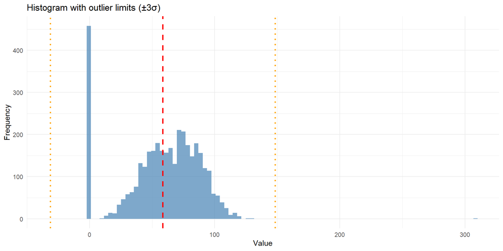

Figure 1: Exploratory data analysis of Plant Height (PH) showcasing distribution behavior and outlier detection. The vertical dotted orange lines and the boxplot’s red markers identify the extreme values candidate for filtering or transformation prior to subsequent statistical modeling.

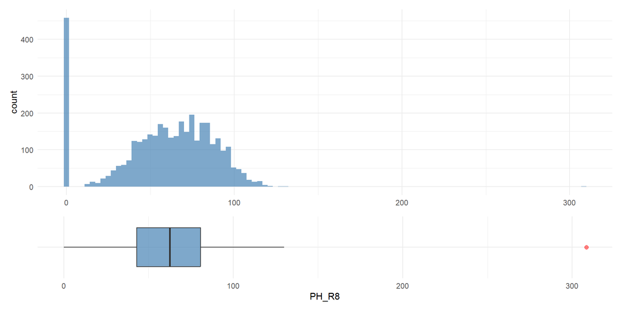

Figure 2: Exploratory data analysis of Plant Height (PH) showcasing distribution behavior and outlier detection. The vertical dotted orange lines and the boxplot’s red markers identify the extreme values candidate for filtering or transformation prior to subsequent statistical modeling.

```r
# Normal Distribution Sd's
ggplot(data, aes(x = PH_R8)) +
  geom_histogram(bins = 100, fill = "steelblue", alpha = 0.7) +
  geom_vline(xintercept = mean(data$PH_R8, na.rm = TRUE),
             color = "red", linetype = "dashed", size = 1) +
  geom_vline(xintercept = mean(data$PH_R8, na.rm = TRUE) +
               c(-3, 3) * sd(data$PH_R8, na.rm = TRUE),
             color = "orange", linetype = "dotted", size = 1) +
  labs(title = "Histogram with outlier limits (±3σ)",
       x = "Value", y = "Frequency") +
  theme_minimal()

# Boxplot outliers
p_hist <- ggplot(data, aes(x = PH_R8)) +
  geom_histogram(bins = 100, fill = "steelblue", alpha = 0.7) +
  theme_minimal() +
  theme(axis.title.x = element_blank())

p_box <- ggplot(data, aes(y = PH_R8, x = "")) +
  geom_boxplot(fill = "steelblue", alpha = 0.7, outlier.color = "red",
               outlier.size = 2, outlier.alpha = 0.5) +
  coord_flip() +
  theme_minimal() +
  theme(axis.title.y = element_blank(),
        axis.text.y = element_blank())

p_hist / p_box + plot_layout(heights = c(3, 1))
```

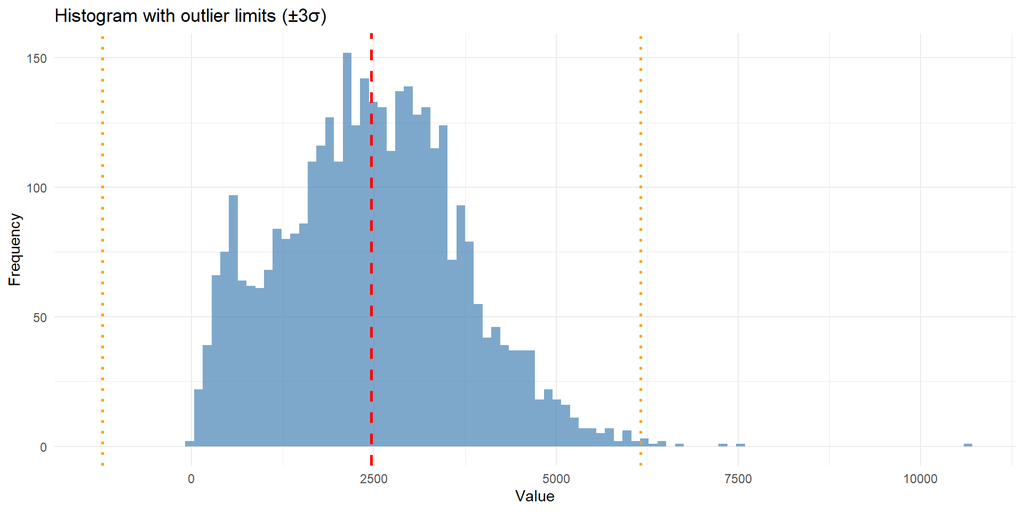

Figure 3: Exploratory data analysis of Grain Yield (GY) showcasing distribution behavior and outlier detection. The vertical dotted orange lines and the boxplot’s red markers identify the extreme values candidate for filtering or transformation prior to subsequent statistical modeling.

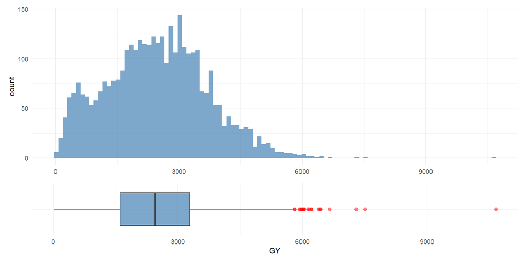

Figure 4: Exploratory data analysis of Grain Yield (GY) showcasing distribution behavior and outlier detection. The vertical dotted orange lines and the boxplot’s red markers identify the extreme values candidate for filtering or transformation prior to subsequent statistical modeling.

```r
# Normal Distribution Sd's
ggplot(data, aes(x = GY)) +
  geom_histogram(bins = 100, fill = "steelblue", alpha = 0.7) +
  geom_vline(xintercept = mean(data$GY, na.rm = TRUE),
             color = "red", linetype = "dashed", size = 1) +
  geom_vline(xintercept = mean(data$GY, na.rm = TRUE) +
               c(-3, 3) * sd(data$GY, na.rm = TRUE),
             color = "orange", linetype = "dotted", size = 1) +
  labs(title = "Histogram with outlier limits (±3σ)",
       x = "Value", y = "Frequency") +
  theme_minimal()

# Boxplot outliers
p_hist <- ggplot(data, aes(x = GY)) +
  geom_histogram(bins = 100, fill = "steelblue", alpha = 0.7) +
  theme_minimal() +
  theme(axis.title.x = element_blank())

p_box <- ggplot(data, aes(y = GY, x = "")) +
  geom_boxplot(fill = "steelblue", alpha = 0.7, outlier.color = "red",
               outlier.size = 2, outlier.alpha = 0.5) +
  coord_flip() +
  theme_minimal() +
  theme(axis.title.y = element_blank(),
        axis.text.y = element_blank())

p_hist / p_box + plot_layout(heights = c(3, 1))

## Removing outliers
df <- data|>
  mutate (GY = case_when(
    GY == 10650.85 ~ NA,
    TRUE ~ GY
  )) |>
  mutate(PH_R8 = case_when(
    PH_R8 == 0 ~ NA,
    PH_R8 == 0.0 ~ NA,
    PH_R8 == 308.33 ~ NA,
    TRUE ~ PH_R8
  ))

## Converting columns
df$YEAR <- as.factor(df$YEAR)
df$loc <- as.factor(df$loc)
df$env <- as.factor(df$env)
df$check <- as.factor(df$check)
df$rep <- as.factor(df$rep)
df$gen <- as.factor(df$gen)
df$RAINFED <- as.factor(df$RAINFED)
```

# Statistical Model

Our dataset comprised 33 trials conducted in Zambia. The experiments were arranged in a Randomized Complete Block Design (RCBD) with 3 blocks and approximately 30 genotypes per trial. Not all genotypes were present across all trials.

For both traits analysed, the statistical model used is describe as follow:

$$y_{ij}=b_{j}+g_{i}+e_{ij}$$

Where:

$b_{j}$ was considered a fixed effect because there are only 3 blocks within each experiment.

$g_{i}$ was considered a random effect, where $g_i \sim N(0, \sigma^2_g)$, since genotypes are samples from a larger breeding population. Additionally, modeling genotypes as random allowed us to recover information and account for the unbalanced nature of the data, as some trials had missing plots.

$e_{ij}$ was considered a random effect, where $e_{ij} \sim N(0, \sigma^2_e)$.

As most trials are completely balanced, the broad-sense heritability was estimated using the simple variance components ratio:

$$H² = \frac{\sigma²_g}{( \sigma²_g + \sigma²_e)}$$

# Trait 1 - GY

```r
# Lista de ambientes
envs_list <- unique(as.character(df$env))

# Verificando dados faltantes para GY em cada ENV
info_env_GH <- df |>
  group_by(env) |>
  summarise(
    obs = n(),
    NAs = sum(is.na(GY)),
    .groups = "drop")

library(asreml)

# Rodando para cada trial isoladamente
singleTrial_models_GY <- list()
singleTrial_varcomp_GY <- list()
singleTrial_blup_GY <- list()
singleTrial_reliability_GY <- list()
tabela_geral_GY <- data.frame(env = character(),LRTstat = numeric(),pvalue = numeric(),significance = logical(), h2 = numeric(), cv = numeric(), stringsAsFactors = FALSE)

for (i in envs_list){

  df_env <- df |> filter(env == i)
  df_env$gen <- as.factor(df_env$gen)
  df_env$rep <- as.factor(df_env$rep)
  i <- as.character(i)

  model <- asreml(fixed = GY ~ rep,
                               random = ~ gen ,
                               data = df_env,
                               maxit = 100,
                               na.action = na.method(y=c("omit")))

  varcomp <- summary(model)$varcomp

  blups <- predict.asreml(model, classify = "gen")$pvals

  blups <- blups[order(blups$predicted.value, decreasing = TRUE),]

  reliability <- 1 - (blups$std.error^2/varcomp[1,1])


  m_red_GY <- asreml(fixed = GY ~ rep,
                               data = df_env,
                               maxit = 100,
                               na.action = na.method(y=c("omit")))

  pval <- lrt(model, m_red_GY, boundary = T)

  h2 <- vpredict(model, H2 ~ V1/(V1+V2))
  cv <- sqrt(varcomp[2,1])/mean(df_env$GY, na.rm=T)

  tabela_geral_GY <- rbind(tabela_geral_GY,
    data.frame(
      env = i,
      LRTstat = round(pval$`LR-statistic`,digits=3),
      pvalue = round(pval$`Pr(Chisq)`,digits=4) ,
      significance = pval$`Pr(Chisq)` < 0.05,
      h2 = round(h2$Estimate,digits=4),
      cv = round((cv*100),digits=2)))

  singleTrial_models_GY[[i]] <- model
  singleTrial_varcomp_GY[[i]] <- varcomp
  singleTrial_blup_GY[[i]] <- blups
  singleTrial_reliability_GY[[i]] <- reliability
  }
```

# Summary of Grain Yield Model Analysis

```r
tabela_geral_GY |>
  mutate(significance = case_when(
    `pvalue` < 0.01 ~ "**",
    `pvalue` < 0.05 ~ "*",
    TRUE             ~ "ns"
  )) |>
  kable(
    align = "c",
    col.names = c(
      "Trial",
      "LRT statistic",
      "p-value",
      "Significance",
      "Broad-sense heritability (H²)",
      "Coefficient of Variation (%)"
    )
  ) |>
  kable_styling(bootstrap_options = "striped", full_width = TRUE) |>
  footnote(
    general = c("* - p < 0.05 (5%);", "** - p < 0.01 (1%);", "ns - non-significant."),
    general_title = "Significance levels: ")
```

Table 1: Agronomic summary of 33 soybean breeding trials for Grain Yield (GY) in Zambia

| Trial | LRT statistic | p-value | Significance | Broad-sense heritability (H²) | Coefficient of Variation (%) |
| --- | --- | --- | --- | --- | --- |
| E0103 | 7.864 | 0.0025 | ** | 0.2728 | 21.53 |
| E0104 | 56.852 | 0.0000 | ** | 0.6869 | 12.01 |
| E0105 | 5.407 | 0.0100 | * | 0.2352 | 32.39 |
| E0106 | 14.448 | 0.0001 | ** | 0.3701 | 19.38 |
| E0107 | 10.373 | 0.0006 | ** | 0.3201 | 42.04 |
| E0108 | 0.000 | 0.5000 | ns | 0.0000 | 44.72 |
| E0169 | 11.433 | 0.0004 | ** | 0.3294 | 18.43 |
| E0170 | 7.751 | 0.0027 | ** | 0.2710 | 29.03 |
| E0171 | 17.096 | 0.0000 | ** | 0.4122 | 15.61 |
| E0172 | 15.669 | 0.0000 | ** | 0.3873 | 14.58 |
| E0173 | 34.353 | 0.0000 | ** | 0.5573 | 14.34 |
| E0174 | 2.692 | 0.0504 | ns | 0.1586 | 25.48 |
| E0175 | 0.000 | 0.5000 | ns | 0.0000 | 31.88 |
| E0176 | 12.601 | 0.0002 | ** | 0.3473 | 17.89 |
| E0224 | 1.345 | 0.1231 | ns | 0.1105 | 18.32 |
| E0225 | 4.803 | 0.0142 | * | 0.2191 | 40.62 |
| E0226 | 17.901 | 0.0000 | ** | 0.4111 | 22.79 |
| E0227 | 189.444 | 0.0000 | ** | 0.9499 | 19.08 |
| E0228 | 34.264 | 0.0000 | ** | 0.5567 | 17.33 |
| E0229 | 110.931 | 0.0000 | ** | 0.8549 | 18.95 |
| E0230 | 56.791 | 0.0000 | ** | 0.6866 | 34.73 |
| E0252 | 29.791 | 0.0000 | ** | 0.5723 | 42.74 |
| E0253 | 31.743 | 0.0000 | ** | 0.6523 | 40.78 |
| E0254 | 51.090 | 0.0000 | ** | 0.7365 | 13.35 |
| E0255 | 58.012 | 0.0000 | ** | 0.7691 | 15.12 |
| E0278 | 12.003 | 0.0003 | ** | 0.3701 | 21.07 |
| E0279 | 10.629 | 0.0006 | ** | 0.3782 | 17.46 |
| E0280 | 1.341 | 0.1234 | ns | 0.1336 | 21.66 |
| E0281 | 2.084 | 0.0744 | ns | 0.1410 | 20.97 |
| E0282 | 19.173 | 0.0000 | ** | 0.4870 | 19.10 |
| E0283 | 22.699 | 0.0000 | ** | 0.5052 | 22.43 |
| E0284 | 58.533 | 0.0000 | ** | 0.7312 | 11.11 |
| E0285 | 0.010 | 0.4597 | ns | 0.0106 | 34.13 |

Significance levels:  
* - p < 0.05 (5%);  
** - p < 0.01 (1%);  
ns - non-significant.

# BLUPs and Reability

In this section we can observe the predicted value of each genotype in each trial individually. There are some environments that have more genotypes or different genotypes. Also, observing the standard errors it is possible to identify what trials are unbalanced.

Here, the BLUPs for Grain Yield (GY) across the trials are presented. The bar charts (see the panel tabset below) illustrate the genotype ranking within each environment. The error bars represent the standard error of the prediction, providing a visual assessment of the reliability of the estimates in each specific trial.

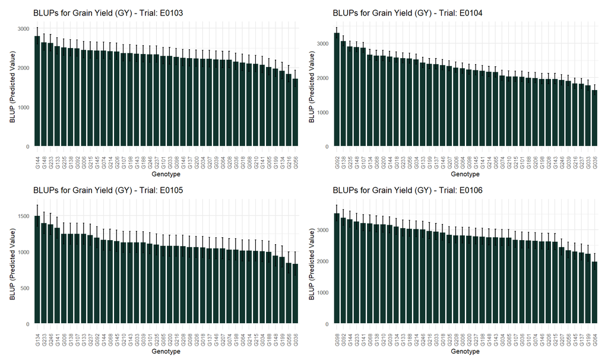

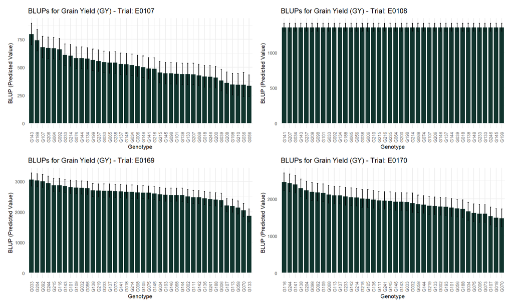

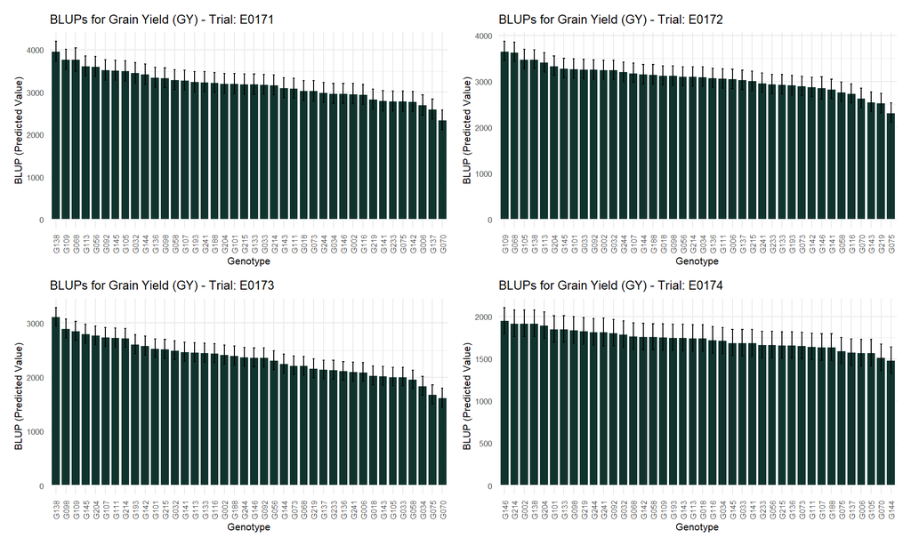

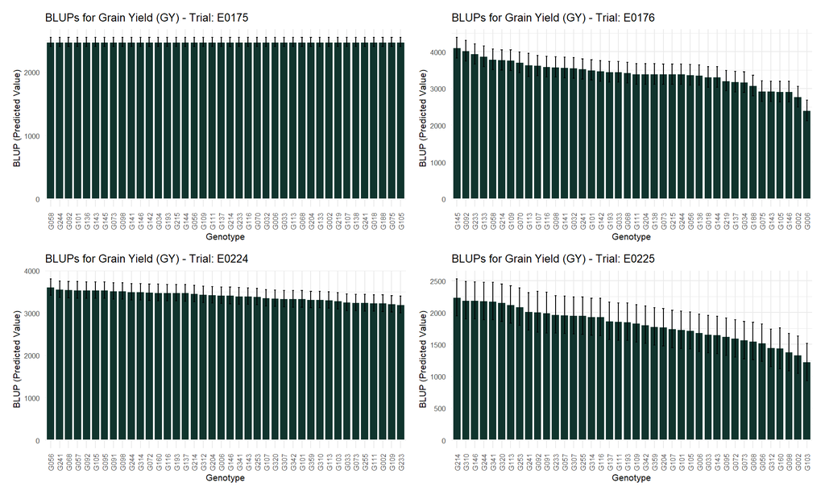

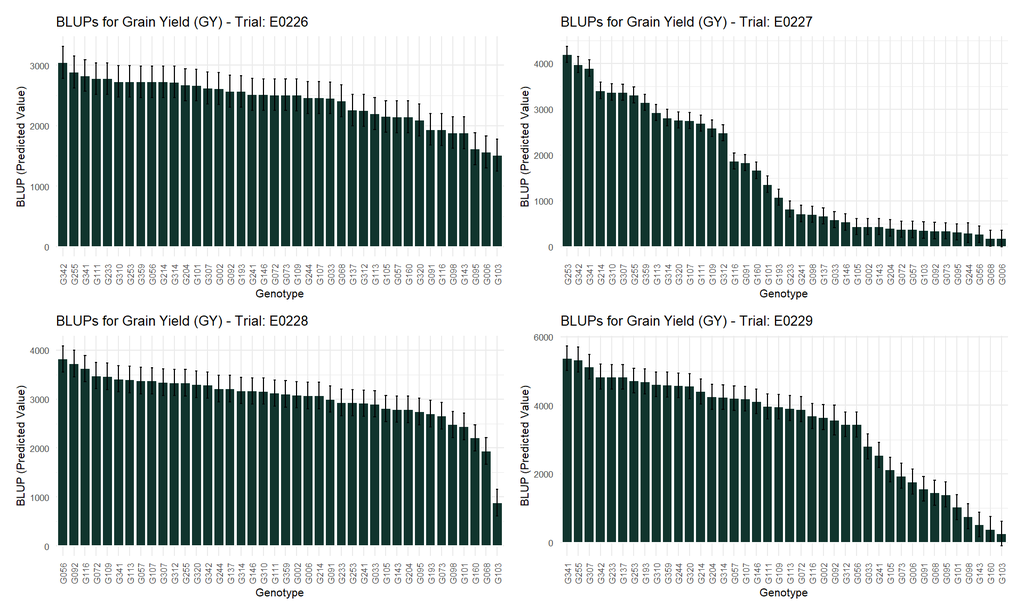

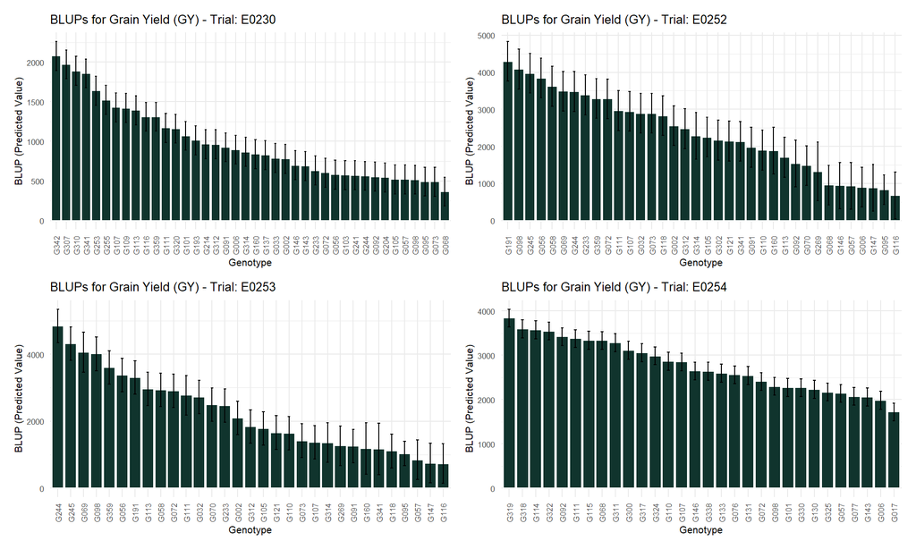

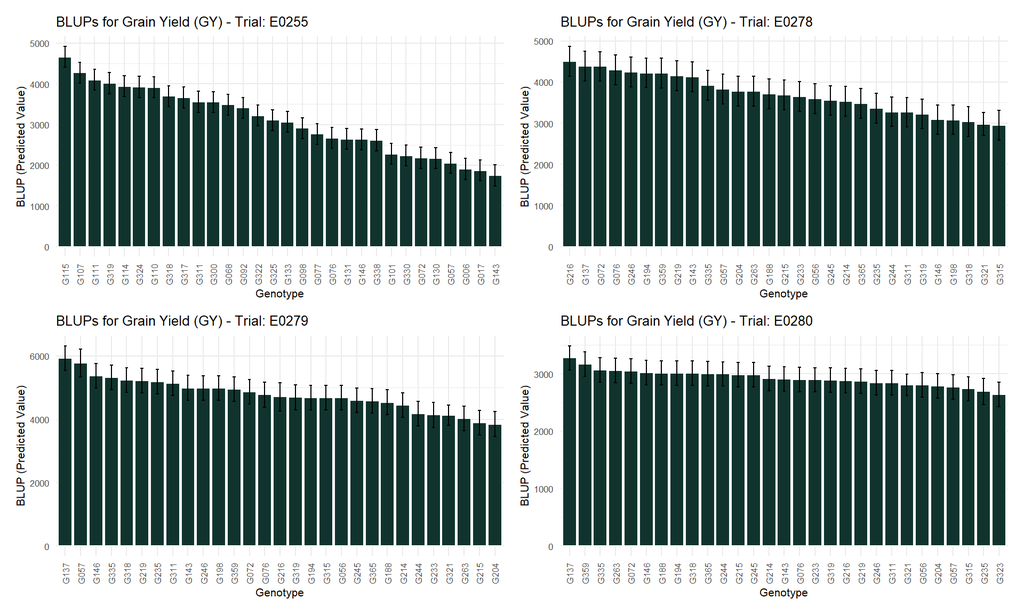

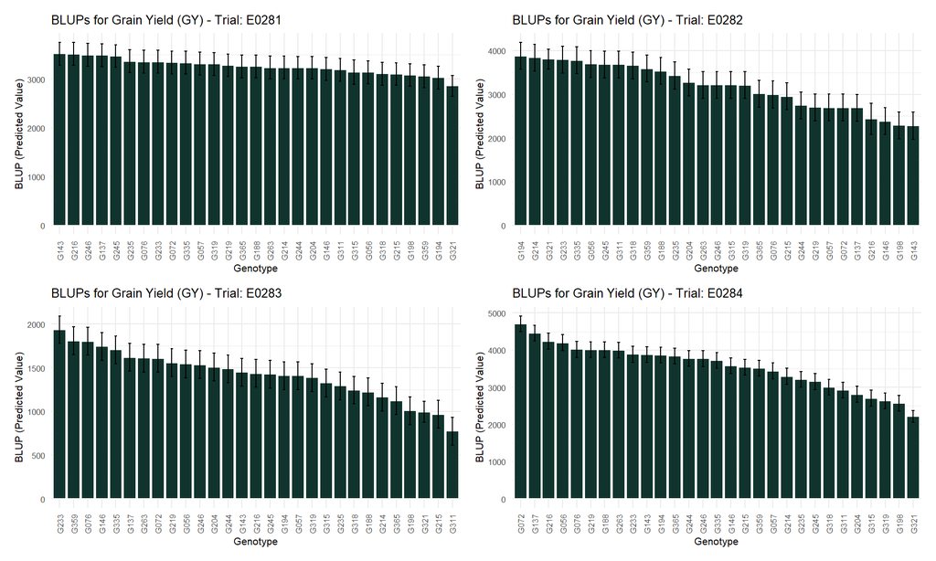

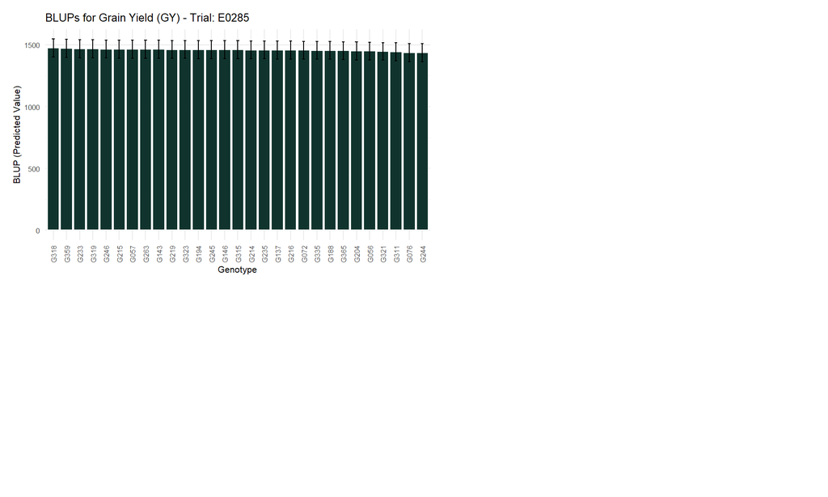

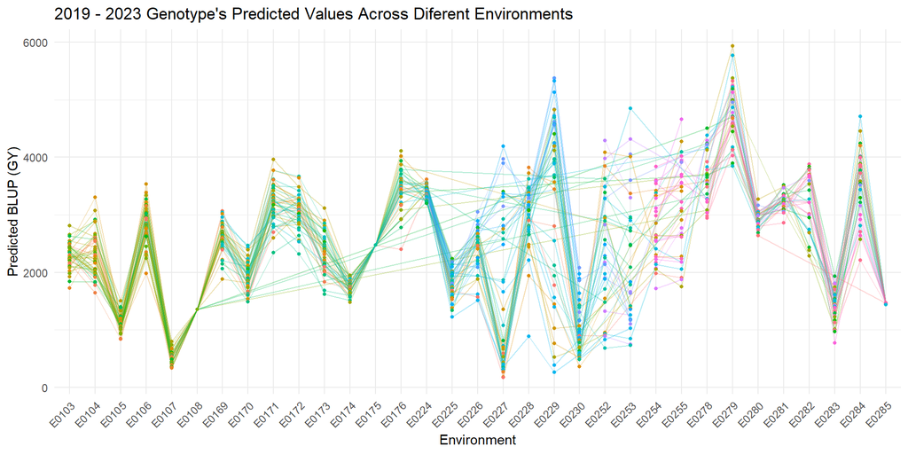

Figure 5: Genotypic performance and temporal stability. The line graph illustrates the BLUP-predicted values (Y-axis) for the grain yield (GY) trait across the 2019 to 2023 period. The horizontal axis discriminates the different testing environments exibiting the genotype-by-environment (G×E) interaction of the soybean breeding genotypes along the years.

```r
blup_all_GY <- bind_rows(
  lapply(names(singleTrial_blup_GY), function(env){
    df <- singleTrial_blup_GY[[env]]
    df$env <- env
    return(df)}))

# subset_1 <- blup_all_GY |> filter(env %in% c("E0252","E0253","E0254","E0255","E0278","E0279","E0280","E0281","E0282","E0283","E0284","E0285"))
#
# subset_2 <- blup_all_GY |> filter(!env %in% c("E0252","E0253","E0254","E0255","E0278","E0279","E0280","E0281","E0282","E0283","E0284","E0285"))
#
# ggplot(subset_1,
#        aes(x = env, y = predicted.value, group = gen, color = gen)) +
#       geom_line(alpha = 0.3) +
#       geom_point(size = 1) +
#       theme_minimal() +
#       labs(x = "Environment", y = "Predicted BLUP (GY)",
#         title = "2022 - 2023 Genotype's Predicted Values Across Diferent Environments") +
#       theme(axis.text.x = element_text(angle = 45, hjust = 1),legend.position = "none")
#
# ggplot(subset_2,
#        aes(x = env, y = predicted.value, group = gen, color = gen)) +
#       geom_line(alpha = 0.3) +
#       geom_point(size = 1) +
#       theme_minimal() +
#       labs(x = "Environment", y = "Predicted BLUP (GY)",
#         title = "2019 - 2021 Genotype's Predicted Values Across Diferent Environments") +
#       theme(axis.text.x = element_text(angle = 45, hjust = 1),legend.position = "none")

ggplot(blup_all_GY,
       aes(x = env, y = predicted.value, group = gen, color = gen)) +
      geom_line(alpha = 0.3) +
      geom_point(size = 1) +
      theme_minimal() +
      labs(x = "Environment", y = "Predicted BLUP (GY)",
        title = "2019 - 2023 Genotype's Predicted Values Across Diferent Environments") +
      theme(axis.text.x = element_text(angle = 45, hjust = 1),legend.position = "none")
```

The visual analysis of the BLUPs in each individual trials reveals a dynamic performance behavior among the genotypes. The fluctuation in the top-ranking positions highlights the presence of a strong Genotype by Environment (GxE) interaction. Also, this can be seen in Figure 5, by the cross-over patterns in the different lines.

While the ranking order shifts depending on the trial, the consistent appearance of certain materials, such as genotypes `G092` and `G233`, at the top of the distribution suggests that these lines possess a degree of wide adaptation and stability across different Zambian environments.

The variation in the magnitude of the error bars across the charts reflects the distinct experimental precisions and levels of unbalanceness among the trials. However, by relying on mixed-model methodology, the information recovery can provide a more precise estimate of these genetic values.

For a comprehensive numerical reference, the predicted values and standard errors for all genotypes across all environments are detailed in Table 2.

```r
selected_trials <- names(singleTrial_blup_GY)
tabela_grande <- singleTrial_blup_GY[selected_trials] |>
  map(~ .x |> select(gen, predicted.value, std.error)) |>
  reduce(full_join, by = "gen")

colunas_valores <- rep(c("Predicted value", "Stand. error"), length(selected_trials))

tabela_grande |>
  kable(
    align = "c",
    col.names = c("Genotype", colunas_valores)
  ) |>
  kable_styling(bootstrap_options = c("striped", "hover", "condensed"), full_width = FALSE) |>
  add_header_above(c(" " = 1, setNames(rep(2, length(selected_trials)), selected_trials))) |>
  scroll_box(width = "100%", height = "600px")
```

Table 2: Predicted values of Grain Yield (kg/ha) and standard errors for grain yield of soybean breeding genotypes evaluated across 33 trials in Zambia.

| Genotype | E0103 Predicted value | E0103 Stand. error | E0104 Predicted value | E0104 Stand. error | E0105 Predicted value | E0105 Stand. error | E0106 Predicted value | E0106 Stand. error | E0107 Predicted value | E0107 Stand. error | E0108 Predicted value | E0108 Stand. error | E0169 Predicted value | E0169 Stand. error | E0170 Predicted value | E0170 Stand. error | E0171 Predicted value | E0171 Stand. error | E0172 Predicted value | E0172 Stand. error | E0173 Predicted value | E0173 Stand. error | E0174 Predicted value | E0174 Stand. error | E0175 Predicted value | E0175 Stand. error | E0176 Predicted value | E0176 Stand. error | E0224 Predicted value | … |
| --- | --- | --- | --- | --- | --- | --- | --- | --- | --- | --- | --- | --- | --- | --- | --- | --- | --- | --- | --- | --- | --- | --- | --- | --- | --- | --- | --- | --- | --- | --- |
| G144 | 2807.944 | 209.708 | 2617.769 | 149.6698 | 1165.6618 | 147.1805 | 3335.737 | 255.7245 | 585.1172 | 96.0511 | 1359.289 | 55.48693 | 2560.050 | 216.4082 | 1850.516 | 238.8785 | 3422.821 | 236.6308 | 3160.689 | 211.0824 | 2248.395 | 173.6033 | 1483.401 | 156.5954 | 2475 | 72.03849 | 3315.824 | 278.7332 | NA | … |
| G148 | 2651.923 | 209.708 | 2895.525 | 149.6698 | 948.2345 | 147.1805 | 2767.955 | 255.7245 | 528.4881 | 96.0511 | 1359.289 | 55.48693 | NA | NA | NA | NA | NA | NA | NA | NA | NA | NA | NA | NA | NA | NA | NA | NA | NA | … |
| G233 | 2631.401 | 209.708 | 2575.050 | 149.6698 | 1400.3541 | 147.1805 | 3269.265 | 255.7245 | 611.8773 | 96.0511 | 1359.289 | 55.48693 | 2701.190 | 216.4082 | 2070.011 | 238.8785 | 2794.143 | 236.6308 | 2941.986 | 211.0824 | 2139.542 | 173.6033 | 1666.656 | 156.5954 | 2475 | 72.03849 | 3938.909 | 278.7332 | 3200.363 | … |
| G133 | 2551.620 | 209.708 | 2440.605 | 149.6698 | 1249.0898 | 147.1805 | 3055.524 | 255.7245 | 440.5787 | 96.0511 | 1359.289 | 55.48693 | 1882.264 | 216.4082 | 1813.162 | 238.8785 | 3188.178 | 236.6308 | 2937.239 | 211.0824 | 2449.050 | 173.6033 | 1851.721 | 156.5954 | 2475 | 72.03849 | 3869.222 | 278.7332 | NA | … |
| G235 | 2519.053 | 209.708 | 2915.815 | 149.6698 | 1101.7242 | 147.1805 | 2841.493 | 255.7245 | 543.0869 | 96.0511 | 1359.289 | 55.48693 | NA | NA | NA | NA | NA | NA | NA | NA | NA | NA | NA | NA | NA | NA | NA | NA | NA | … |
| G138 | 2502.517 | 209.708 | 3071.360 | 149.6698 | 1250.4144 | 147.1805 | 3183.116 | 255.7245 | 441.1174 | 96.0511 | 1359.289 | 55.48693 | 2715.098 | 216.4082 | 2295.227 | 238.8785 | 3961.169 | 236.6308 | 3482.988 | 211.0824 | 3114.408 | 173.6033 | 1918.253 | 156.5954 | 2475 | 72.03849 | 3393.709 | 278.7332 | NA | … |
| G092 | 2494.589 | 209.708 | 3306.653 | 149.6698 | 1199.9567 | 147.1805 | 3389.960 | 255.7245 | 662.9928 | 96.0511 | 1359.289 | 55.48693 | 3018.401 | 216.4082 | 2178.935 | 238.8785 | 3524.270 | 236.6308 | 3265.265 | 211.0824 | 2362.738 | 173.6033 | 1805.815 | 156.5954 | 2475 | 72.03849 | 4020.894 | 278.7332 | 3543.103 | … |
| G006 | 2453.971 | 209.708 | 2300.694 | 149.6698 | 1251.6095 | 147.1805 | 2824.307 | 255.7245 | 512.6772 | 96.0511 | 1359.289 | 55.48693 | 2395.482 | 216.4082 | 1607.475 | 238.8785 | 2696.060 | 236.6308 | 3055.495 | 211.0824 | 2095.880 | 173.6033 | 1571.748 | 156.5954 | 2475 | 72.03849 | 2397.593 | 278.7332 | 3419.437 | … |
| G215 | 2450.510 | 209.708 | 2036.465 | 149.6698 | 1015.7765 | 147.1805 | 2619.856 | 255.7245 | 456.4091 | 96.0511 | 1359.289 | 55.48693 | 2887.314 | 216.4082 | 2012.367 | 238.8785 | 3188.933 | 236.6308 | 3015.725 | 211.0824 | 2522.493 | 173.6033 | 1662.640 | 156.5954 | 2475 | 72.03849 | 3389.610 | 278.7332 | NA | … |
| G145 | 2441.995 | 209.708 | 2227.006 | 149.6698 | 1150.0125 | 147.1805 | 2312.899 | 255.7245 | 448.1865 | 96.0511 | 1359.289 | 55.48693 | 2616.554 | 216.4082 | 1947.173 | 238.8785 | 3514.396 | 236.6308 | 3290.830 | 211.0824 | 2804.842 | 173.6033 | 1691.664 | 156.5954 | 2475 | 72.03849 | 4106.978 | 278.7332 | NA | … |
| G074 | 2437.744 | 209.708 | 2066.544 | 149.6698 | 1032.4736 | 147.1805 | 2648.580 | 255.7245 | 585.1524 | 96.0511 | 1359.289 | 55.48693 | NA | NA | NA | NA | NA | NA | NA | NA | NA | NA | NA | NA | NA | NA | NA | NA | NA | … |
| G214 | 2421.835 | 209.708 | 2178.630 | 149.6698 | 1016.8996 | 147.1805 | 3027.047 | 255.7245 | 606.4535 | 96.0511 | 1359.289 | 55.48693 | 2662.947 | 216.4082 | 2043.025 | 238.8785 | 3172.153 | 236.6308 | 3108.208 | 211.0824 | 2723.709 | 173.6033 | 1920.460 | 156.5954 | 2475 | 72.03849 | 3774.939 | 278.7332 | 3461.271 | … |
| G206 | 2416.163 | 209.708 | 1997.072 | 149.6698 | 1065.1687 | 147.1805 | 2630.784 | 255.7245 | 674.1781 | 96.0511 | 1359.289 | 55.48693 | NA | NA | NA | NA | NA | NA | NA | NA | NA | NA | NA | NA | NA | NA | NA | NA | NA | … |
| G107 | 2374.340 | 209.708 | 2877.602 | 149.6698 | 1249.6609 | 147.1805 | 2687.134 | 255.7245 | 680.9936 | 96.0511 | 1359.289 | 55.48693 | 2220.398 | 216.4082 | 1537.111 | 238.8785 | 3283.611 | 236.6308 | 3186.153 | 211.0824 | 2738.850 | 173.6033 | 1640.432 | 156.5954 | 2475 | 72.03849 | 3623.267 | 278.7332 | 3360.260 | … |
| G198 | 2373.881 | 209.708 | 1970.942 | 149.6698 | 1031.7377 | 147.1805 | 2786.804 | 255.7245 | 349.4314 | 96.0511 | 1359.289 | 55.48693 | NA | NA | NA | NA | NA | NA | NA | NA | NA | NA | NA | NA | NA | NA | NA | NA | NA | … |
| G143 | 2357.284 | 209.708 | 1969.762 | 149.6698 | 1133.7954 | 147.1805 | 2760.205 | 255.7245 | 797.1170 | 96.0511 | 1359.289 | 55.48693 | 2854.552 | 216.4082 | 1926.817 | 238.8785 | 3105.720 | 236.6308 | 2559.873 | 211.0824 | 2020.120 | 173.6033 | 1752.574 | 156.5954 | 2475 | 72.03849 | 2922.296 | 278.7332 | 3397.983 | … |
| G188 | 2349.983 | 209.708 | 2001.357 | 149.6698 | 999.6873 | 147.1805 | 3041.467 | 255.7245 | 742.8397 | 96.0511 | 1359.289 | 55.48693 | 2411.401 | 216.4082 | 1732.503 | 238.8785 | 3228.827 | 236.6308 | 3154.032 | 211.0824 | 2398.082 | 173.6033 | 1638.512 | 156.5954 | 2475 | 72.03849 | 3082.167 | 278.7332 | NA | … |
| G246 | 2345.919 | 209.708 | 1934.691 | 149.6698 | 1383.5850 | 147.1805 | 3012.767 | 255.7245 | 418.8229 | 96.0511 | 1359.289 | 55.48693 | NA | NA | NA | NA | NA | NA | NA | NA | NA | NA | NA | NA | NA | NA | NA | NA | NA | … |
| G237 | 2340.395 | 209.708 | 1828.849 | 149.6698 | 1234.2516 | 147.1805 | 2794.384 | 255.7245 | 558.5172 | 96.0511 | 1359.289 | 55.48693 | NA | NA | NA | NA | NA | NA | NA | NA | NA | NA | NA | NA | NA | NA | NA | NA | NA | … |
| G101 | 2303.970 | 209.708 | 2034.616 | 149.6698 | 1116.8039 | 147.1805 | 2664.984 | 255.7245 | 444.2401 | 96.0511 | 1359.289 | 55.48693 | 2820.432 | 216.4082 | 1767.507 | 238.8785 | 3199.207 | 236.6308 | 3277.910 | 211.0824 | 2534.626 | 173.6033 | 1853.330 | 156.5954 | 2475 | 72.03849 | 3504.389 | 278.7332 | 3333.056 | … |
| G033 | 2299.738 | 209.708 | 1778.295 | 149.6698 | 1133.0035 | 147.1805 | 2943.411 | 255.7245 | 548.5186 | 96.0511 | 1359.289 | 55.48693 | 3064.342 | 216.4082 | 1918.075 | 238.8785 | 3183.592 | 236.6308 | 3270.494 | 211.0824 | 2009.436 | 173.6033 | 1689.387 | 156.5954 | 2475 | 72.03849 | 3451.099 | 278.7332 | 3252.030 | … |
| G098 | 2279.000 | 209.708 | 2243.635 | 149.6698 | 1067.1733 | 147.1805 | 3532.779 | 255.7245 | 448.0655 | 96.0511 | 1359.289 | 55.48693 | 2647.533 | 216.4082 | 2197.301 | 238.8785 | 3339.567 | 236.6308 | 3131.866 | 211.0824 | 2899.058 | 173.6033 | 1838.398 | 156.5954 | 2475 | 72.03849 | 3586.374 | 278.7332 | 3522.522 | … |
| G146 | 2254.053 | 209.708 | 2374.866 | 149.6698 | 1048.6748 | 147.1805 | 2634.206 | 255.7245 | 503.7559 | 96.0511 | 1359.289 | 55.48693 | 2563.841 | 216.4082 | 1926.927 | 238.8785 | 2972.702 | 236.6308 | 2861.437 | 239.7467 | 2365.249 | 173.6033 | 1950.337 | 156.5954 | 2475 | 72.03849 | 2918.197 | 278.7332 | 3414.172 | … |
| G137 | 2247.608 | 209.708 | 2401.362 | 149.6698 | 1049.4459 | 147.1805 | 2283.488 | 255.7245 | 531.5952 | 96.0511 | 1359.289 | 55.48693 | 2698.519 | 216.4082 | 2100.395 | 238.8785 | 2597.562 | 236.6308 | 3036.802 | 211.0824 | 2142.391 | 173.6033 | 1578.471 | 156.5954 | 2475 | 72.03849 | 3180.549 | 278.7332 | 3475.241 | … |
| G200 | 2241.290 | 209.708 | 2644.934 | 149.6698 | 1083.1521 | 147.1805 | 2818.220 | 255.7245 | 410.9867 | 96.0511 | 1359.289 | 55.48693 | NA | NA | NA | NA | NA | NA | NA | NA | NA | NA | NA | NA | NA | NA | NA | NA | NA | … |
| G034 | 2230.886 | 209.708 | 2537.651 | 149.6698 | 1007.7519 | 147.1805 | 2752.578 | 255.7245 | 522.4631 | 96.0511 | 1359.289 | 55.48693 | 2586.163 | 216.4082 | 1666.056 | 238.8785 | 2972.964 | 236.6308 | 3104.474 | 211.0824 | 1836.870 | 173.6033 | 1714.351 | 156.5954 | 2475 | 72.03849 | 3168.251 | 278.7332 | NA | … |
| G207 | 2227.554 | 209.708 | 2342.750 | 149.6698 | 1047.2766 | 147.1805 | 2447.063 | 255.7245 | 440.2976 | 96.0511 | 1359.289 | 55.48693 | NA | NA | NA | NA | NA | NA | NA | NA | NA | NA | NA | NA | NA | NA | NA | NA | NA | … |
| G039 | 2218.058 | 209.708 | 1913.479 | 149.6698 | 1131.5524 | 147.1805 | 3153.242 | 255.7245 | 385.2084 | 96.0511 | 1359.289 | 55.48693 | NA | NA | NA | NA | NA | NA | NA | NA | NA | NA | NA | NA | NA | NA | NA | NA | NA | … |
| G064 | 2207.792 | 209.708 | 2276.671 | 149.6698 | 1017.0275 | 147.1805 | 1985.284 | 255.7245 | 671.1784 | 96.0511 | 1359.289 | 55.48693 | NA | NA | NA | NA | NA | NA | NA | NA | NA | NA | NA | NA | NA | NA | NA | NA | NA | … |
| G208 | 2203.853 | 209.708 | 1970.017 | 149.6698 | 1080.0821 | 147.1805 | 2827.166 | 255.7245 | 363.0622 | 96.0511 | 1359.289 | 55.48693 | NA | NA | NA | NA | NA | NA | NA | NA | NA | NA | NA | NA | NA | NA | NA | NA | NA | … |

[output cut: 77 more lines]

As shown in Table 3, filtering for trials with a CV under 30% and positive genetic variance resulted in the selection of 20 out of 33 trials. This high retention rate reflects the solid experimental quality of the breeding program. Furthermore, the highlighted genotypes indicate those that recur across different trials or maintain top positions within the ranking, showcasing their high yield potential and stability across environments in Zambia.

```r
low_cv_envs <- tabela_geral_GY |>
  select(env, h2, cv, significance) |>
  filter(significance == "TRUE" & cv < 30) |>
  arrange(cv)

envs <- low_cv_envs$env

genotipos_repetidos <- singleTrial_blup_GY[envs] |>
  map_dfr(~ .x |> arrange(desc(predicted.value)) |> head(5) |> select(gen)) |>
  count(gen) |>
  filter(n > 1) |>
  pull(gen) |>
  as.character()

set.seed(42)
cores_paleta <- hcl.colors(length(genotipos_repetidos), palette = "Greens 2") |>
  paste0("80")
mapa_cores <- setNames(cores_paleta, genotipos_repetidos)

tabela_longa <- envs |>
  set_names() |>
  map_dfr(~ {
    singleTrial_blup_GY[[.x]] |>
      arrange(desc(predicted.value)) |>
      head(5) |>
      select(gen, predicted.value) |>
      mutate(
        rank = c("1st", "2nd", "3rd", "4th", "5th"),
        gen = as.character(gen)
      )
  }, .id = "env")

tabela_larga <- tabela_longa |>
  pivot_wider(
    id_cols = env,
    names_from = rank,
    values_from = c(gen, predicted.value),
    names_glue = "{rank}_{.value}"
  ) |>
  select(
    env,
    `1st_gen`, `1st_predicted.value`,
    `2nd_gen`, `2nd_predicted.value`,
    `3rd_gen`, `3rd_predicted.value`,
    `4th_gen`, `4th_predicted.value`,
    `5th_gen`, `5th_predicted.value`
  )

sub_colunas <- c("Trial", rep(c("Genotype", "Predicted value"), 5))

tabela_final <- kbl(tabela_larga, align = "c", col.names = sub_colunas) |>
  kable_styling(bootstrap_options = c("striped", "hover", "condensed"), full_width = FALSE) |>
  add_header_above(c(" " = 1, "1st" = 2, "2nd" = 2, "3rd" = 2, "4th" = 2, "5th" = 2))

colunas_indices <- c(2, 4, 6, 8, 10)

for (col in colunas_indices) {
  valores_coluna <- as.character(tabela_larga[[col]])

  marcar_negrito <- valores_coluna %in% genotipos_repetidos

  cores_fundo <- ifelse(marcar_negrito, mapa_cores[valores_coluna], "transparent")
  cores_fundo[is.na(cores_fundo)] <- "transparent"

  tabela_final <- tabela_final |>
    column_spec(
      column = col,
      bold = marcar_negrito,
      background = cores_fundo
    )
}

tabela_final
```

Table 3: Predicted value of Grain Yield (GY) of the top five soybean breeding genotypes ranked (1 to 5) in each trial in Zambia

| Trial | 1st Genotype | 1st Predicted value | 2nd Genotype | 2nd Predicted value | 3rd Genotype | 3rd Predicted value | 4th Genotype | 4th Predicted value | 5th Genotype | 5th Predicted value |
| --- | --- | --- | --- | --- | --- | --- | --- | --- | --- | --- |
| E0284 | G072 | 4707.557 | G137 | 4452.474 | G216 | 4237.724 | G056 | 4197.952 | G076 | 4017.146 |
| E0104 | G092 | 3306.653 | G138 | 3071.360 | G235 | 2915.815 | G148 | 2895.525 | G107 | 2877.602 |
| E0254 | G319 | 3841.144 | G318 | 3596.266 | G114 | 3573.156 | G322 | 3545.945 | G092 | 3418.736 |
| E0173 | G138 | 3114.408 | G098 | 2899.058 | G109 | 2855.030 | G145 | 2804.842 | G204 | 2771.493 |
| E0172 | G109 | 3662.982 | G068 | 3638.844 | G105 | 3486.159 | G138 | 3482.988 | G113 | 3419.679 |
| E0255 | G115 | 4660.496 | G107 | 4272.438 | G111 | 4095.564 | G319 | 4015.744 | G114 | 3942.892 |
| E0171 | G138 | 3961.169 | G109 | 3775.926 | G068 | 3768.815 | G113 | 3615.213 | G056 | 3606.110 |
| E0228 | G056 | 3821.612 | G092 | 3723.889 | G116 | 3624.586 | G072 | 3480.504 | G109 | 3464.436 |
| E0279 | G137 | 5936.230 | G057 | 5773.763 | G146 | 5372.017 | G335 | 5326.481 | G318 | 5240.904 |
| E0176 | G145 | 4106.978 | G092 | 4020.894 | G233 | 3938.909 | G133 | 3869.222 | G058 | 3787.237 |
| E0169 | G033 | 3064.342 | G204 | 3037.850 | G092 | 3018.401 | G244 | 2957.251 | G215 | 2887.314 |
| E0229 | G341 | 5375.962 | G255 | 5330.238 | G307 | 5125.185 | G342 | 4835.313 | G233 | 4825.428 |
| E0227 | G253 | 4188.436 | G342 | 3969.745 | G341 | 3895.123 | G214 | 3406.016 | G310 | 3371.293 |
| E0282 | G194 | 3880.696 | G214 | 3838.106 | G321 | 3806.201 | G233 | 3794.263 | G335 | 3777.474 |
| E0106 | G098 | 3532.779 | G092 | 3389.960 | G144 | 3335.737 | G233 | 3269.265 | G141 | 3220.860 |
| E0278 | G216 | 4504.268 | G137 | 4384.926 | G072 | 4381.332 | G076 | 4294.138 | G246 | 4243.584 |
| E0103 | G144 | 2807.944 | G148 | 2651.923 | G233 | 2631.401 | G133 | 2551.620 | G235 | 2519.053 |
| E0283 | G233 | 1935.773 | G359 | 1808.245 | G076 | 1802.852 | G146 | 1743.250 | G335 | 1705.476 |
| E0226 | G342 | 3046.583 | G255 | 2889.376 | G341 | 2827.874 | G111 | 2778.781 | G233 | 2778.307 |
| E0170 | G116 | 2463.141 | G244 | 2430.488 | G141 | 2394.492 | G138 | 2295.227 | G204 | 2239.885 |

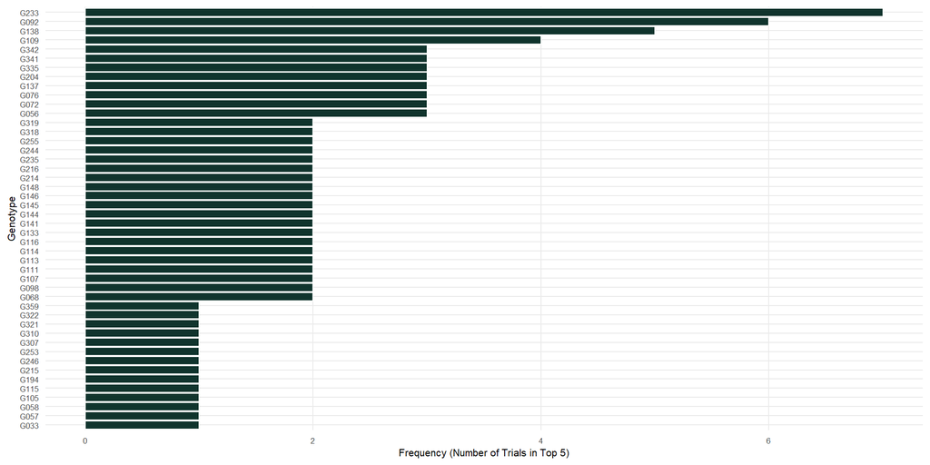

Figure 6: Frequency of each genotype in the top five genotypes in each trial

```r
# How many times a genotype appears in the table
frequencia_geral <- tabela_larga |>
  select(env, ends_with("_gen")) |>
  pivot_longer(cols = ends_with("_gen"), values_to = "genotipo") |>
  count(genotipo, name = "total_ambientes") |>
  arrange(desc(total_ambientes))

ggplot(data = frequencia_geral, aes(x = total_ambientes, y = reorder(genotipo, total_ambientes))) +
  geom_col(color = "white", fill = "#10342d") +
  theme_minimal() +
  labs(
    x = "Frequency (Number of Trials in Top 5)",
    y = "Genotype"
  ) +
  theme(
    text = element_text(size = 08),
    panel.grid.minor = element_blank()
  )
```

```r
G233 <- tabela_longa |> select (gen, env, rank, predicted.value) |> filter(gen == "G233" ) |> arrange(rank)
kable(G233,
      align = "c",
      col.names = c("Genotype","Environment", "Rank position", "Predicted value")) |>
kable_styling(bootstrap_options = c("striped", "hover", "condensed"), full_width = FALSE)

G092 <- tabela_longa |> select (gen, env, rank, predicted.value) |> filter(gen == "G092" ) |> arrange(rank)
kable(G092,
      align = "c",
      col.names = c("Genotype","Environment", "Rank position", "Predicted value")) |>
kable_styling(bootstrap_options = c("striped", "hover", "condensed"), full_width = FALSE)
```

Table 4: Behavior of the two most frequent genotypes across ranked environments

| Genotype | Environment | Rank position | Predicted value |
| --- | --- | --- | --- |
| G233 | E0283 | 1st | 1935.773 |
| G233 | E0176 | 3rd | 3938.909 |
| G233 | E0103 | 3rd | 2631.401 |
| G233 | E0282 | 4th | 3794.263 |
| G233 | E0106 | 4th | 3269.265 |
| G233 | E0229 | 5th | 4825.428 |
| G233 | E0226 | 5th | 2778.307 |

| Genotype | Environment | Rank position | Predicted value |
| --- | --- | --- | --- |
| G092 | E0104 | 1st | 3306.653 |
| G092 | E0228 | 2nd | 3723.889 |
| G092 | E0176 | 2nd | 4020.894 |
| G092 | E0106 | 2nd | 3389.960 |
| G092 | E0169 | 3rd | 3018.401 |
| G092 | E0254 | 5th | 3418.736 |

A closer examination of the two most frequent genotypes highlights contrasting adaptive strategies. Genotype `G092` emerges as a highly stable material with wide adaptation; it consistently secures top-tier rankings (predominantly 1st and 2nd) and maintains reliable predicted values across diverse conditions. Conversely, genotype `G233` exhibits phenotypic plasticity. It is highly responsive to environments, eaching a peak predicted yield of over 4,800 kg/ha in trial `E0229`, but experiences significant yield penalties in more restrictive environments (dropping to approximately 1,935 kg/ha in `E0283`).

From a practical breeding perspective, `G092` is highly recommended for broad geographical deployment to ensure yield stability. Meanwhile, `G233` represents a valuable asset for targeted selection, strategically suited for high-yielding Target Population of Environments (TPEs). Ultimately, these distinct behavioral patterns definitively validate the necessity of characterizing Genotype-by-Environment (GxE) interactions in multi-environment trial evaluations.

# Trait 2 - Plant Height (PH)

```r
# Removendo ambientes com nenhuma observação
df <- df |> filter(!env %in% c("E0171","E0172","E0225"))
envs_list <- envs_list[!envs_list %in% c("E0171","E0172","E0225")]

# Verificando dados faltantes para PH em cada ENV
info_env_PH <- df |>
  group_by(env) |>
  summarise(
    obs = n(),
    NAs = sum(is.na(PH_R8)),
    .groups = "drop")

# Rodando para cada trial isoladamente
singleTrial_models_PH <- list()
singleTrial_varcomp_PH <- list()
singleTrial_blup_PH <- list()
singleTrial_reliability_PH <- list()
tabela_geral_PH <- data.frame(env = character(),LRTstat = numeric(),pvalue = numeric(),significance = logical(), h2 = numeric(), cv = numeric(), stringsAsFactors = FALSE)

for (i in envs_list){

  df_env <- df |> filter(env == i)
  df_env$gen <- as.factor(df_env$gen)
  df_env$rep <- as.factor(df_env$rep)
  i <- as.character(i)

  model <- asreml(fixed = PH_R8 ~ rep,
                               random = ~ gen ,
                               data = df_env,
                               maxit = 100,
                               na.action = na.method(y=c("omit")))

  varcomp <- summary(model)$varcomp

  blups <- predict.asreml(model, classify = "gen")$pvals

  blups <- blups[order(blups$predicted.value, decreasing = TRUE),]

  reliability <- 1 - (blups$std.error^2/varcomp[1,1])


  m_red_PH <- asreml(fixed = PH_R8 ~ rep,
                               data = df_env,
                               maxit = 100,
                               na.action = na.method(y=c("omit")))

  pval <- lrt(model, m_red_PH, boundary = T)


  h2 <- vpredict(model, H2 ~ V1/(V1+V2))
  cv <- sqrt(varcomp[2,1])/mean(df_env$PH, na.rm=T)

  tabela_geral_PH <- rbind(tabela_geral_PH,
    data.frame(
      env = i,
      LRTstat = round(pval$`LR-statistic`,digits=3),
      pvalue = round(pval$`Pr(Chisq)`,digits=4) ,
      significance = pval$`Pr(Chisq)` < 0.05,
      h2 = round(h2$Estimate,digits=4),
      cv = round((cv*100),digits=2)))

  singleTrial_models_PH[[i]] <- model
  singleTrial_varcomp_PH[[i]] <- varcomp
  singleTrial_blup_PH[[i]] <- blups
  singleTrial_reliability_PH[[i]] <- reliability
  }
```

# Summary of Plant Height Model Analysis

```r
tabela_geral_PH |>
  mutate(significance = case_when(
    `pvalue` < 0.01 ~ "**",
    `pvalue` < 0.05 ~ "*",
    TRUE             ~ "ns"
  )) |>
  kable(
    align = "c",
    col.names = c(
    "Trial",
    "LRT statistic",
    "p-value",
    "Significance",
    "Broad-sense heritability (H²)",
    "Coefficient of Variation (%)"
  )) |>
  kable_styling(bootstrap_options = "striped", full_width = TRUE)|>
  footnote(
    general = paste("* - p < 0.05 (5%);", "** - p < 0.01 (1%);", "ns - non-significant."),
    general_title = "Significance levels: ",
    threeparttable = TRUE)
```

| Trial | LRT statistic | p-value | Significance | Broad-sense heritability (H²) | Coefficient of Variation (%) |
| --- | --- | --- | --- | --- | --- |
| E0103 | 21.652 | 0.0000 | ** | 0.4505 | 16.65 |
| E0104 | 20.914 | 0.0000 | ** | 0.4431 | 14.04 |
| E0105 | 25.351 | 0.0000 | ** | 0.4936 | 19.85 |
| E0106 | 61.286 | 0.0000 | ** | 0.7066 | 9.33 |
| E0107 | 12.417 | 0.0002 | ** | 0.3480 | 20.51 |
| E0108 | 0.149 | 0.3497 | ns | 0.0361 | 27.18 |
| E0169 | 80.622 | 0.0000 | ** | 0.7775 | 10.08 |
| E0170 | 0.000 | 0.5000 | ns | 0.0000 | 22.51 |
| E0173 | 77.214 | 0.0000 | ** | 0.7665 | 6.58 |
| E0174 | 13.979 | 0.0001 | ** | 0.3642 | 11.90 |
| E0175 | 37.269 | 0.0000 | ** | 0.5776 | 14.28 |
| E0176 | 74.528 | 0.0000 | ** | 0.7575 | 10.51 |
| E0224 | 62.382 | 0.0000 | ** | 0.7112 | 11.59 |
| E0226 | 40.751 | 0.0000 | ** | 0.6002 | 13.86 |
| E0227 | 62.178 | 0.0000 | ** | 0.7104 | 10.08 |
| E0228 | 94.026 | 0.0000 | ** | 0.8153 | 9.57 |
| E0229 | 69.892 | 0.0000 | ** | 0.7633 | 12.09 |
| E0230 | 0.000 | 0.5000 | ns | 0.0000 | 23.46 |
| E0252 | 22.824 | 0.0000 | ** | 0.5197 | 18.33 |
| E0253 | 9.944 | 0.0008 | ** | 0.6539 | 16.45 |
| E0254 | 8.316 | 0.0020 | ** | 0.3258 | 13.86 |
| E0255 | 91.643 | 0.0000 | ** | 0.8758 | 6.66 |
| E0278 | 17.500 | 0.0000 | ** | 0.4438 | 13.68 |
| E0279 | 20.663 | 0.0000 | ** | 0.4983 | 9.90 |
| E0280 | 24.211 | 0.0000 | ** | 0.5202 | 10.61 |
| E0281 | 12.829 | 0.0002 | ** | 0.3553 | 9.71 |
| E0282 | 43.786 | 0.0000 | ** | 0.6652 | 6.63 |
| E0283 | 25.928 | 0.0000 | ** | 0.5457 | 14.53 |
| E0284 | 32.928 | 0.0000 | ** | 0.6012 | 9.59 |
| E0285 | 27.819 | 0.0000 | ** | 0.5392 | 12.67 |

Significance levels:  
* - p < 0.05 (5%); ** - p < 0.01 (1%); ns - non-significant.

# BLUPs and Reability

In this section we can observe the predicted value of each genotype in each trial individually. There are some environments that have more genotypes or different genotypes. Also, observing the standard errors it is possible to identify what trials are unbalanced.

Here, we present the BLUPs for Plant Height (PH) across the trials. The bar charts (see the panel tabset below) illustrate the genotype ranking within each environment. We used error bars to represent the standard error of the prediction, providing a visual assessment of the reliability of our predictions in each specific trial.

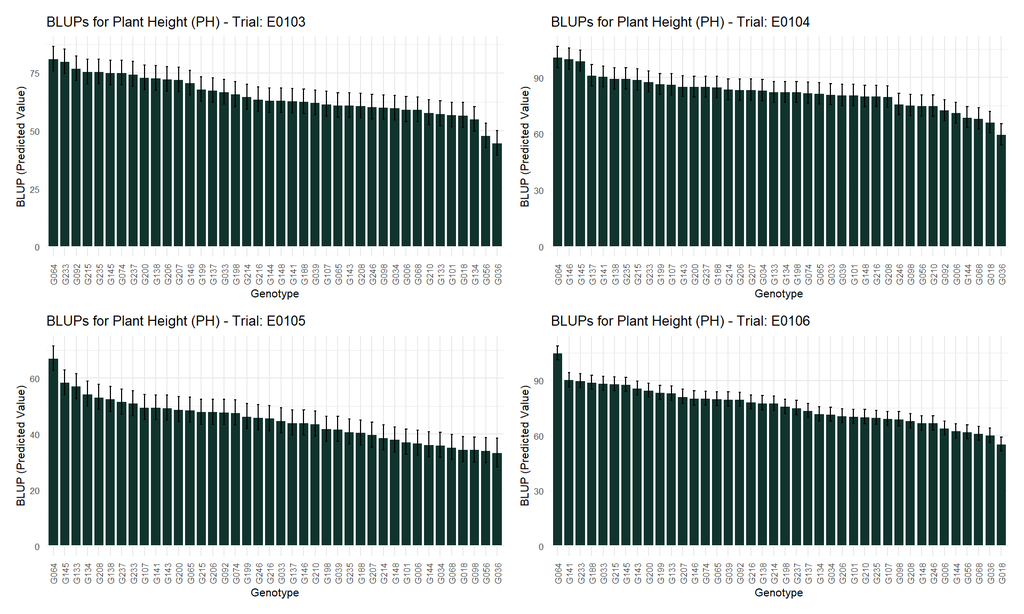

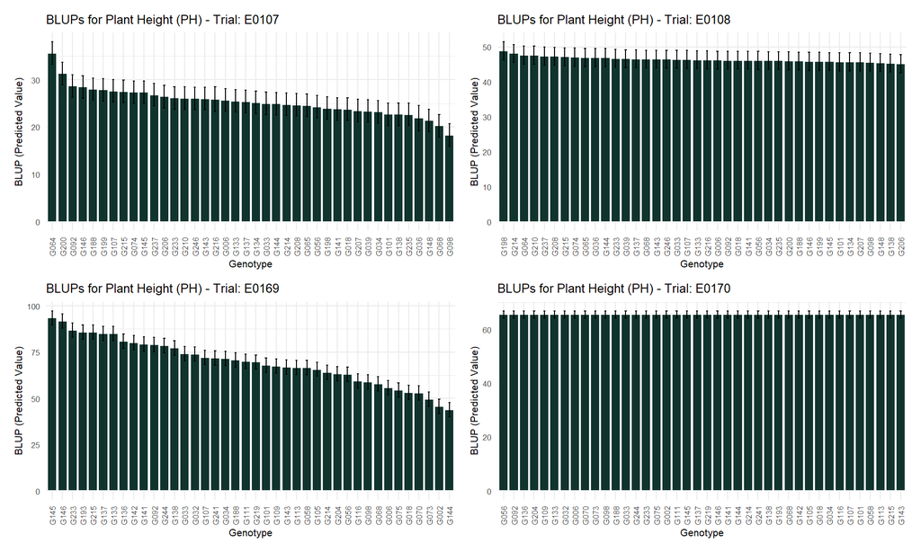

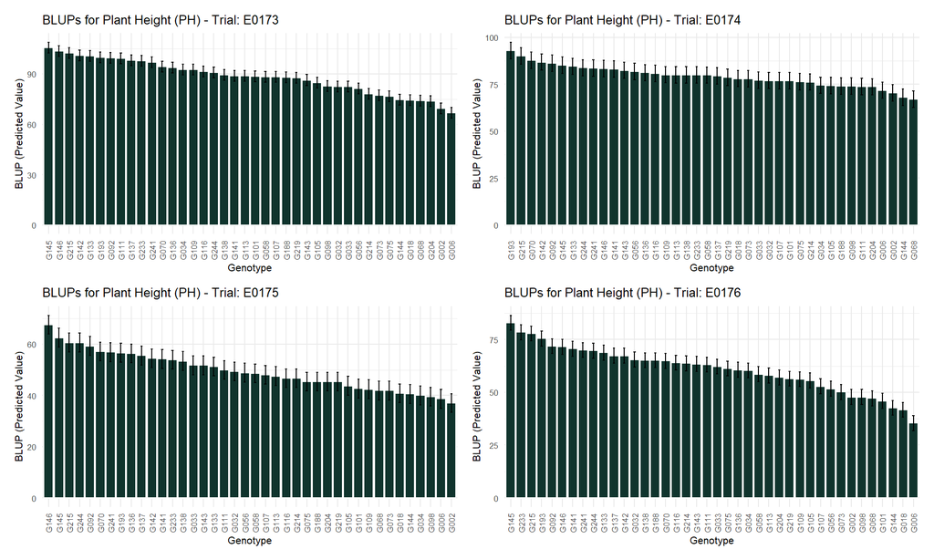

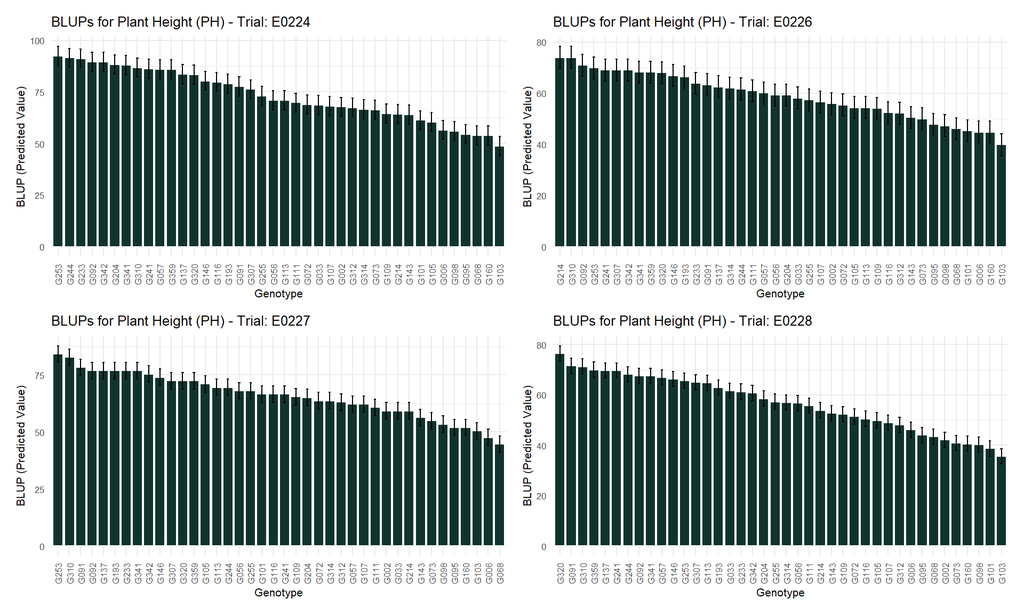

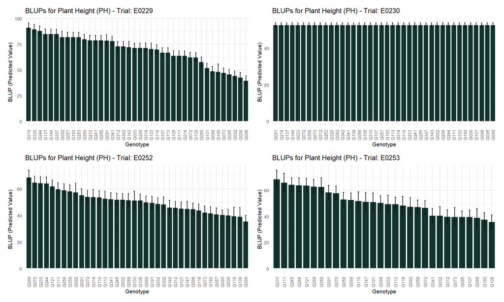

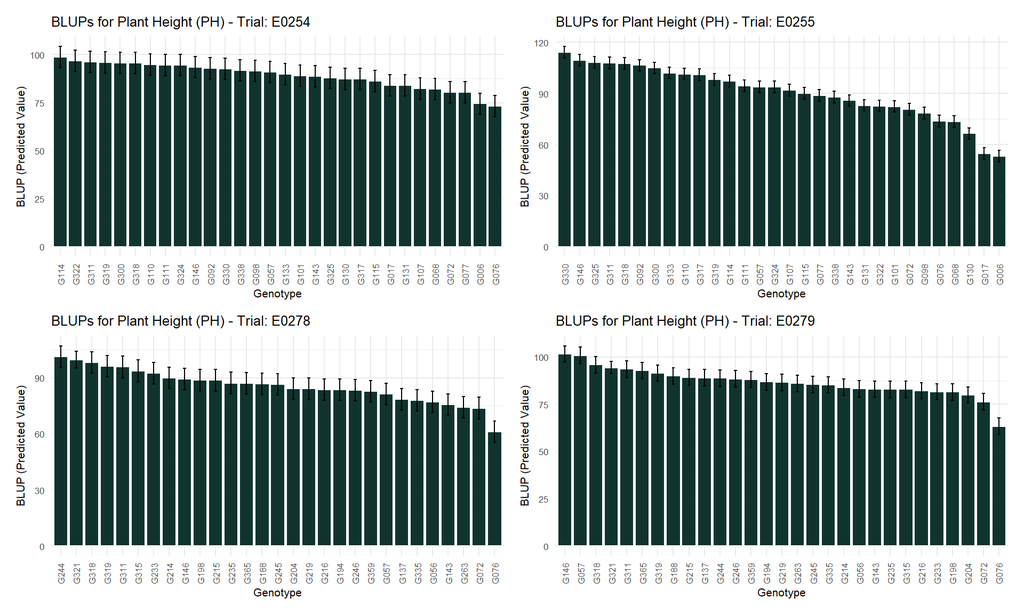

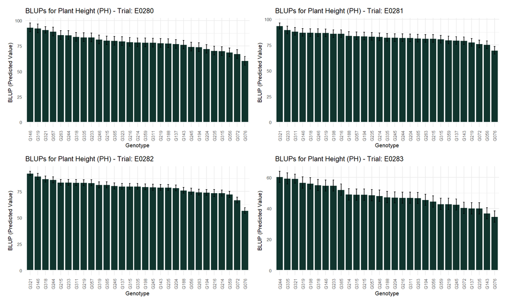

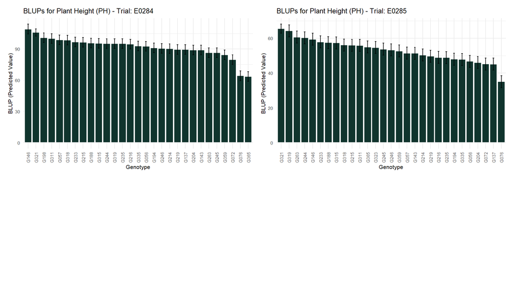

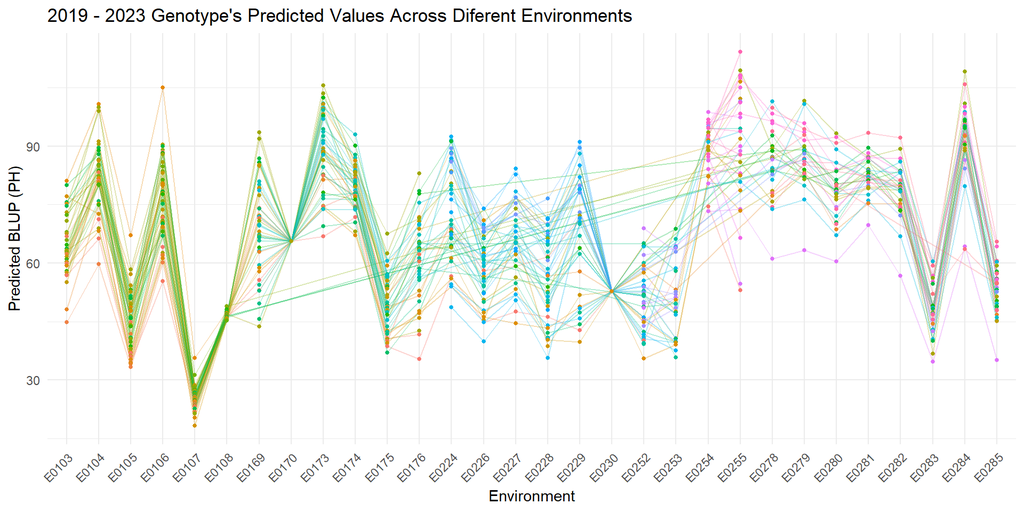

Figure 7: Ppredicted values for Plant Height (PH) and respective genotype rankings across individual trials. Each bar chart displays the performance rank within a specific trial.

```r
blup_all_PH <- bind_rows(
  lapply(names(singleTrial_blup_PH), function(env){
    df <- singleTrial_blup_PH[[env]]
    df$env <- env
    return(df)}))

# subset_1 <- blup_all_PH |> filter(env %in% c("E0252","E0253","E0254","E0255","E0278","E0279","E0280","E0281","E0282","E0283","E0284","E0285"))
#
# subset_2 <- blup_all_PH |> filter(!env %in% c("E0252","E0253","E0254","E0255","E0278","E0279","E0280","E0281","E0282","E0283","E0284","E0285"))
#
# ggplot(subset_1,
#        aes(x = env, y = predicted.value, group = gen, color = gen)) +
#       geom_line(alpha = 0.3) +
#       geom_point(size = 1) +
#       theme_minimal() +
#       labs(x = "Environment", y = "Predicted BLUP (PH)",
#         title = "2022 - 2023 Genotype's Predicted Values Across Diferent Environments") +
#       theme(axis.text.x = element_text(angle = 45, hjust = 1),legend.position = "none")
#
# ggplot(subset_2,
#        aes(x = env, y = predicted.value, group = gen, color = gen)) +
#       geom_line(alpha = 0.3) +
#       geom_point(size = 1) +
#       theme_minimal() +
#       labs(x = "Environment", y = "Predicted BLUP (PH)",
#         title = "2019 - 2021 Genotype's Predicted Values Across Diferent Environments") +
#       theme(axis.text.x = element_text(angle = 45, hjust = 1),legend.position = "none")

ggplot(blup_all_PH,
       aes(x = env, y = predicted.value, group = gen, color = gen)) +
      geom_line(alpha = 0.3) +
      geom_point(size = 1) +
      theme_minimal() +
      labs(x = "Environment", y = "Predicted BLUP (PH)",
        title = "2019 - 2023 Genotype's Predicted Values Across Diferent Environments") +
      theme(axis.text.x = element_text(angle = 45, hjust = 1),legend.position = "none")
```

Our visual analysis of the BLUPs for Plant Height (PH) across the individual trials reveals substantial variation among environments, as observed in Figure 7. In trials with non-significant genetic variance (such as `E0108`, `E0170`, and `E0230`), we observe that the genotype distributions appear flat, reflecting the lack of genetic differentiation. Conversely, in highly heritable environments, we can see a clear genetic gradient. The generally low standard errors and tight error bars visually confirm the high experimental precision (low CV%) of our breeding trials.

For a comprehensive numerical reference, we detailed the predicted values and standard errors for all genotypes across all environments in Table 6.

```r
selected_trials <- names(singleTrial_blup_PH)
tabela_grande <- singleTrial_blup_PH[selected_trials] |>
  map(~ .x |> select(gen, predicted.value, std.error)) |>
  reduce(full_join, by = "gen")

colunas_valores <- rep(c("Predicted value", "Stand. error"), length(selected_trials))

tabela_grande |>
  kable(
    align = "c",
    col.names = c("Genotype", colunas_valores)
  ) |>
  kable_styling(bootstrap_options = c("striped", "hover", "condensed"), full_width = FALSE) |>
  add_header_above(c(" " = 1, setNames(rep(2, length(selected_trials)), selected_trials))) |>
  scroll_box(width = "100%", height = "600px")
```

| Genotype | E0103 Predicted value | E0103 Stand. error | E0104 Predicted value | E0104 Stand. error | E0105 Predicted value | E0105 Stand. error | E0106 Predicted value | E0106 Stand. error | E0107 Predicted value | E0107 Stand. error | E0108 Predicted value | E0108 Stand. error | E0169 Predicted value | E0169 Stand. error | E0170 Predicted value | E0170 Stand. error | E0173 Predicted value | E0173 Stand. error | E0174 Predicted value | E0174 Stand. error | E0175 Predicted value | E0175 Stand. error | E0176 Predicted value | E0176 Stand. error | E0224 Predicted value | E0224 Stand. error | E0226 Predicted value | E0226 Stand. error | E0227 Predicted value | … |
| --- | --- | --- | --- | --- | --- | --- | --- | --- | --- | --- | --- | --- | --- | --- | --- | --- | --- | --- | --- | --- | --- | --- | --- | --- | --- | --- | --- | --- | --- | --- |
| G064 | 81.13089 | 5.312635 | 100.83088 | 5.616494 | 67.09097 | 4.476615 | 105.07110 | 3.852508 | 35.62551 | 2.374019 | 47.67100 | 2.562863 | NA | NA | NA | NA | NA | NA | NA | NA | NA | NA | NA | NA | NA | NA | NA | NA | NA | … |
| G233 | 79.94595 | 5.312635 | 87.91002 | 5.616494 | 50.99553 | 4.476615 | 89.96235 | 3.852508 | 26.12604 | 2.374019 | 46.76215 | 2.562863 | 86.76620 | 3.876233 | 65.61408 | 1.348516 | 97.71533 | 3.202928 | 79.94213 | 4.361741 | 53.92031 | 3.669291 | 78.46001 | 3.518349 | 91.23899 | 4.611557 | 63.88104 | 4.270157 | 76.84683 | … |
| G092 | 77.10210 | 5.312635 | 72.63992 | 5.616494 | 47.86586 | 4.476615 | 79.83129 | 3.852508 | 28.67017 | 2.374019 | 46.21683 | 2.562863 | 79.03702 | 3.876233 | 65.61409 | 1.348516 | 99.53098 | 3.202928 | 86.26309 | 4.361741 | 59.28024 | 3.669291 | 71.83389 | 3.518349 | 89.47739 | 4.611557 | 70.97298 | 4.270157 | 76.84683 | … |
| G215 | 75.58537 | 5.312635 | 88.84972 | 5.616494 | 48.01489 | 4.476615 | 88.14696 | 3.852508 | 27.50069 | 2.374019 | 47.18628 | 2.562863 | 85.79244 | 3.876233 | 65.61408 | 1.348516 | 102.40575 | 3.202928 | 90.13994 | 4.361741 | 60.62023 | 3.669291 | 77.85764 | 3.518349 | NA | NA | NA | NA | NA | … |
| G235 | 75.56167 | 5.312635 | 89.55449 | 5.616494 | 40.81169 | 4.476615 | 69.93448 | 3.852508 | 22.67914 | 2.374019 | 46.08892 | 2.562863 | NA | NA | NA | NA | NA | NA | NA | NA | NA | NA | NA | NA | NA | NA | NA | NA | NA | … |
| G145 | 75.25359 | 5.312635 | 98.95148 | 5.616494 | 58.42229 | 4.476615 | 87.91271 | 3.852508 | 27.33655 | 2.374019 | 45.81963 | 2.562863 | 93.46076 | 3.876233 | 65.61408 | 1.348516 | 105.58314 | 3.202928 | 85.20960 | 4.361741 | 62.49620 | 3.669291 | 82.97782 | 3.518349 | NA | NA | NA | NA | NA | … |
| G074 | 75.18249 | 5.312635 | 81.80198 | 5.616494 | 47.66715 | 4.476615 | 80.41690 | 3.852508 | 27.33655 | 2.374019 | 47.09539 | 2.562863 | NA | NA | NA | NA | NA | NA | NA | NA | NA | NA | NA | NA | NA | NA | NA | NA | NA | … |
| G237 | 74.61372 | 5.312635 | 85.09092 | 5.616494 | 51.59166 | 4.476615 | 75.20497 | 3.852508 | 26.82362 | 2.374019 | 47.36805 | 2.562863 | NA | NA | NA | NA | NA | NA | NA | NA | NA | NA | NA | NA | NA | NA | NA | NA | NA | … |
| G200 | 73.07330 | 5.312635 | 85.09092 | 5.616494 | 48.80973 | 4.476615 | 84.75042 | 3.852508 | 31.29638 | 2.374019 | 45.98794 | 2.562863 | NA | NA | NA | NA | NA | NA | NA | NA | NA | NA | NA | NA | NA | NA | NA | NA | NA | … |
| G138 | 72.95481 | 5.312635 | 89.55449 | 5.616494 | 52.58520 | 4.476615 | 77.86950 | 3.852508 | 22.72018 | 2.374019 | 45.38204 | 2.562863 | 77.33295 | 3.876233 | 65.61408 | 1.348516 | 89.45413 | 3.202928 | 79.94213 | 4.361741 | 53.38432 | 3.669291 | 65.20778 | 3.518349 | NA | NA | NA | NA | NA | … |
| G206 | 72.38603 | 5.312635 | 83.44645 | 5.616494 | 47.94038 | 4.476615 | 70.81289 | 3.852508 | 26.43380 | 2.374019 | 45.20700 | 2.562863 | NA | NA | NA | NA | NA | NA | NA | NA | NA | NA | NA | NA | NA | NA | NA | NA | NA | … |
| G207 | 72.26754 | 5.312635 | 83.44645 | 5.616494 | 39.76846 | 4.476615 | 81.35388 | 3.852508 | 23.45880 | 2.374019 | 45.71865 | 2.562863 | NA | NA | NA | NA | NA | NA | NA | NA | NA | NA | NA | NA | NA | NA | NA | NA | NA | … |
| G146 | 70.77452 | 5.312635 | 99.89118 | 5.616494 | 44.04071 | 4.476615 | 80.47546 | 3.852508 | 28.46500 | 2.374019 | 45.88696 | 2.562863 | 91.87841 | 3.876233 | 65.61408 | 1.348516 | 103.55567 | 3.202928 | 83.41866 | 4.361741 | 67.58814 | 3.669291 | 71.53271 | 3.518349 | 80.37577 | 4.611557 | 66.88147 | 4.270157 | 73.91229 | … |
| G199 | 67.97806 | 5.312635 | 86.50047 | 5.616494 | 46.40038 | 4.476615 | 83.57920 | 3.852508 | 27.84948 | 2.374019 | 45.85329 | 2.562863 | NA | NA | NA | NA | NA | NA | NA | NA | NA | NA | NA | NA | NA | NA | NA | NA | NA | … |
| G137 | 67.50408 | 5.312635 | 91.19896 | 5.616494 | 44.09039 | 4.476615 | 73.68238 | 3.852508 | 25.36690 | 2.374019 | 46.59384 | 2.562863 | 85.12299 | 3.876233 | 65.61408 | 1.348516 | 98.16924 | 3.202928 | 79.52073 | 4.361741 | 55.52829 | 3.669291 | 67.31609 | 3.518349 | 83.60538 | 4.611557 | 62.51720 | 4.270157 | 76.84683 | … |
| G033 | 66.88791 | 5.312635 | 81.09720 | 5.616494 | 44.88522 | 4.476615 | 88.43976 | 3.852508 | 24.97707 | 2.374019 | 46.45920 | 2.562863 | 74.16825 | 3.876233 | 65.61408 | 1.348516 | 82.49415 | 3.202928 | 77.24519 | 4.361741 | 51.77634 | 3.669291 | 62.19591 | 3.518349 | 68.63175 | 4.611557 | 58.15293 | 4.270157 | 59.23959 | … |
| G198 | 65.86887 | 5.312635 | 82.27183 | 5.616494 | 41.85491 | 4.476615 | 75.90770 | 3.852508 | 23.95121 | 2.374019 | 48.91646 | 2.562863 | NA | NA | NA | NA | NA | NA | NA | NA | NA | NA | NA | NA | NA | NA | NA | NA | NA | … |
| G214 | 64.73132 | 5.312635 | 83.68138 | 5.616494 | 38.72524 | 4.476615 | 77.66453 | 3.852508 | 24.79242 | 2.374019 | 48.17592 | 2.562863 | 64.00469 | 3.876233 | 65.61408 | 1.348516 | 78.07608 | 3.202928 | 76.23383 | 4.361741 | 46.68440 | 3.669291 | 63.70184 | 3.518349 | 64.22775 | 4.611557 | 73.97341 | 4.270157 | 59.23959 | … |
| G216 | 63.71227 | 5.312635 | 80.15751 | 5.616494 | 45.72974 | 4.476615 | 78.36726 | 3.852508 | 25.87451 | 2.674514 | 46.29089 | 2.562863 | NA | NA | NA | NA | NA | NA | NA | NA | NA | NA | NA | NA | NA | NA | NA | NA | NA | … |
| G144 | 63.23830 | 5.312635 | 68.88112 | 5.616494 | 36.24138 | 4.476615 | 62.55579 | 3.852508 | 24.91552 | 2.374019 | 46.96411 | 2.562863 | 43.73842 | 3.876233 | 65.61408 | 1.348516 | 74.71713 | 3.202928 | 68.14300 | 4.361741 | 40.52048 | 3.669291 | 42.61875 | 3.518349 | NA | NA | NA | NA | NA | … |
| G148 | 63.16720 | 5.312635 | 80.15751 | 5.616494 | 38.02976 | 4.476615 | 66.94786 | 3.852508 | 21.40708 | 2.374019 | 45.51668 | 2.562863 | NA | NA | NA | NA | NA | NA | NA | NA | NA | NA | NA | NA | NA | NA | NA | NA | NA | … |
| G141 | 62.93021 | 5.312635 | 90.49419 | 5.616494 | 49.55489 | 4.476615 | 90.43084 | 3.852508 | 23.80759 | 2.374019 | 46.18991 | 2.562863 | 79.34132 | 3.876233 | 65.61408 | 1.348516 | 88.93970 | 3.202928 | 83.10261 | 4.361741 | 54.18831 | 3.669291 | 70.62915 | 3.518349 | NA | NA | NA | NA | NA | … |
| G188 | 62.74062 | 5.312635 | 84.85600 | 5.616494 | 40.56330 | 4.476615 | 89.02537 | 3.852508 | 27.99310 | 2.374019 | 45.95428 | 2.562863 | 70.88183 | 3.876233 | 65.61408 | 1.348516 | 88.03188 | 3.202928 | 74.02150 | 4.361741 | 45.34442 | 3.669291 | 65.20778 | 3.518349 | NA | NA | NA | NA | NA | … |
| G039 | 62.36144 | 5.312635 | 80.62736 | 5.616494 | 41.75556 | 4.476615 | 79.88985 | 3.852508 | 23.35621 | 2.374019 | 46.66116 | 2.562863 | NA | NA | NA | NA | NA | NA | NA | NA | NA | NA | NA | NA | NA | NA | NA | NA | NA | … |
| G107 | 61.72158 | 5.312635 | 86.26555 | 5.616494 | 49.60457 | 4.476615 | 69.34887 | 3.852508 | 27.62379 | 2.374019 | 46.42553 | 2.562863 | 72.15988 | 3.876233 | 65.61408 | 1.348516 | 88.33449 | 3.202928 | 76.99235 | 4.361741 | 48.02439 | 3.669291 | 52.85911 | 3.518349 | 68.04455 | 4.611557 | 56.51633 | 4.270157 | 62.17413 | … |
| G065 | 61.15280 | 5.312635 | 81.56705 | 5.616494 | 48.66070 | 4.476615 | 80.12410 | 3.852508 | 24.56673 | 2.374019 | 46.99777 | 2.562863 | NA | NA | NA | NA | NA | NA | NA | NA | NA | NA | NA | NA | NA | NA | NA | NA | NA | … |
| G143 | 61.05801 | 5.312635 | 85.32585 | 5.616494 | 49.45554 | 4.476615 | 85.92164 | 3.852508 | 26.00293 | 2.374019 | 46.52652 | 2.562863 | 66.98681 | 3.876233 | 65.61408 | 1.348516 | 86.36753 | 3.202928 | 82.47051 | 4.361741 | 51.77634 | 3.669291 | 63.40066 | 3.518349 | 63.93414 | 4.611557 | 50.51546 | 4.270157 | 56.30505 | … |
| G208 | 61.01061 | 5.312635 | 79.92258 | 5.616494 | 53.18133 | 4.476615 | 68.06052 | 3.852508 | 24.66931 | 2.374019 | 47.32765 | 2.562863 | NA | NA | NA | NA | NA | NA | NA | NA | NA | NA | NA | NA | NA | NA | NA | NA | NA | … |
| G246 | 60.41814 | 5.312635 | 75.92886 | 5.616494 | 46.02780 | 4.476615 | 66.94786 | 3.852508 | 26.04397 | 2.374019 | 46.49286 | 2.562863 | NA | NA | NA | NA | NA | NA | NA | NA | NA | NA | NA | NA | NA | NA | NA | NA | NA | … |
| G098 | 60.22855 | 5.312635 | 75.22409 | 5.616494 | 34.45299 | 4.476615 | 69.17318 | 3.852508 | 18.32949 | 2.374019 | 45.62776 | 2.562863 | 58.83162 | 3.876233 | 65.61408 | 1.348516 | 82.73624 | 3.202928 | 74.00043 | 4.361741 | 39.44849 | 3.669291 | 47.73893 | 3.518349 | 56.00693 | 4.611557 | 47.24225 | 4.270157 | 53.37051 | … |

[output cut: 77 more lines]

```r
low_cv_envs <- tabela_geral_PH |>
  select(env, h2, cv, significance) |>
  filter(significance == "TRUE" & cv < 30) |>
  arrange(cv)

envs <- low_cv_envs$env

genotipos_repetidos <- singleTrial_blup_PH[envs] |>
  map_dfr(~ .x |> arrange(desc(predicted.value)) |> head(5) |> select(gen)) |>
  count(gen) |>
  filter(n > 1) |>
  pull(gen) |>
  as.character()

set.seed(42)
cores_paleta <- hcl.colors(length(genotipos_repetidos), palette = "Greens 2") |>
  paste0("80")
mapa_cores <- setNames(cores_paleta, genotipos_repetidos)

tabela_longa <- envs |>
  set_names() |>
  map_dfr(~ {
    singleTrial_blup_PH[[.x]] |>
      arrange(desc(predicted.value)) |>
      head(5) |>
      select(gen, predicted.value) |>
      mutate(
        rank = c("1st", "2nd", "3rd", "4th", "5th"),
        gen = as.character(gen)
      )
  }, .id = "env")

tabela_larga <- tabela_longa |>
  pivot_wider(
    id_cols = env,
    names_from = rank,
    values_from = c(gen, predicted.value),
    names_glue = "{rank}_{.value}"
  ) |>
  select(
    env,
    `1st_gen`, `1st_predicted.value`,
    `2nd_gen`, `2nd_predicted.value`,
    `3rd_gen`, `3rd_predicted.value`,
    `4th_gen`, `4th_predicted.value`,
    `5th_gen`, `5th_predicted.value`
  )

sub_colunas <- c("Trial", rep(c("Genotype", "Predicted value"), 5))

tabela_final <- kbl(tabela_larga, align = "c", col.names = sub_colunas) |>
  kable_styling(bootstrap_options = c("striped", "hover", "condensed"), full_width = FALSE) |>
  add_header_above(c(" " = 1, "1st" = 2, "2nd" = 2, "3rd" = 2, "4th" = 2, "5th" = 2))

colunas_indices <- c(2, 4, 6, 8, 10)

for (col in colunas_indices) {
  valores_coluna <- as.character(tabela_larga[[col]])

  marcar_negrito <- valores_coluna %in% genotipos_repetidos

  cores_fundo <- ifelse(marcar_negrito, mapa_cores[valores_coluna], "transparent")
  cores_fundo[is.na(cores_fundo)] <- "transparent"

  tabela_final <- tabela_final |>
    column_spec(
      column = col,
      bold = marcar_negrito,
      background = cores_fundo
    )
}

tabela_final
```

Table 7: Predicted value of Plant Height (PH) of the top five soybean breeding genotypes ranked (1 to 5) in each trial in Zambia

| Trial | 1st Genotype | 1st Predicted value | 2nd Genotype | 2nd Predicted value | 3rd Genotype | 3rd Predicted value | 4th Genotype | 4th Predicted value | 5th Genotype | 5th Predicted value |
| --- | --- | --- | --- | --- | --- | --- | --- | --- | --- | --- |
| E0173 | G145 | 105.58314 | G146 | 103.55567 | G215 | 102.40575 | G142 | 100.89272 | G133 | 100.74141 |
| E0282 | G321 | 92.22215 | G146 | 89.27529 | G318 | 86.80330 | G244 | 86.03829 | G215 | 83.66049 |
| E0255 | G330 | 114.21228 | G146 | 109.43789 | G325 | 108.16472 | G311 | 107.84643 | G318 | 107.52814 |
| E0106 | G064 | 105.07110 | G141 | 90.43084 | G233 | 89.96235 | G188 | 89.02537 | G033 | 88.43976 |
| E0228 | G320 | 76.51042 | G091 | 71.55153 | G310 | 71.24160 | G359 | 70.00187 | G137 | 69.69194 |
| E0284 | G146 | 109.12023 | G321 | 105.79442 | G198 | 100.87620 | G311 | 100.05725 | G057 | 98.74694 |
| E0281 | G321 | 93.43043 | G233 | 89.61528 | G311 | 88.23201 | G146 | 87.19144 | G318 | 87.12290 |
| E0279 | G146 | 101.64790 | G057 | 100.81682 | G318 | 95.82531 | G321 | 94.32877 | G311 | 93.57913 |
| E0169 | G145 | 93.46076 | G146 | 91.87841 | G233 | 86.76620 | G193 | 85.85330 | G215 | 85.79244 |
| E0227 | G253 | 84.18318 | G310 | 82.71591 | G091 | 78.31410 | G092 | 76.84683 | G137 | 76.84683 |
| E0176 | G145 | 82.97782 | G233 | 78.46001 | G215 | 77.85764 | G193 | 75.44814 | G092 | 71.83389 |
| E0280 | G146 | 93.26165 | G319 | 92.24187 | G321 | 90.79069 | G057 | 89.18251 | G263 | 85.78408 |
| E0224 | G253 | 92.41339 | G244 | 91.53259 | G233 | 91.23899 | G092 | 89.47739 | G342 | 89.47739 |
| E0174 | G193 | 93.00545 | G215 | 90.13994 | G070 | 87.73798 | G142 | 86.89518 | G092 | 86.26309 |
| E0229 | G310 | 91.09060 | G320 | 89.58010 | G244 | 88.06960 | G137 | 85.04859 | G146 | 85.04859 |
| E0285 | G321 | 65.43455 | G319 | 64.21612 | G263 | 60.58394 | G244 | 60.23889 | G146 | 59.37495 |
| E0278 | G244 | 101.50599 | G321 | 99.78021 | G318 | 98.29217 | G319 | 96.33144 | G311 | 95.86124 |
| E0226 | G214 | 73.97341 | G310 | 73.97341 | G092 | 70.97298 | G253 | 69.88191 | G241 | 69.06361 |
| E0254 | G114 | 98.71614 | G322 | 96.74343 | G311 | 96.15162 | G319 | 95.95435 | G300 | 95.55981 |
| E0104 | G064 | 100.83088 | G146 | 99.89118 | G145 | 98.95148 | G137 | 91.19896 | G141 | 90.49419 |
| E0175 | G146 | 67.58814 | G145 | 62.49620 | G215 | 60.62023 | G244 | 60.62023 | G092 | 59.28024 |
| E0283 | G244 | 60.48247 | G335 | 59.35267 | G321 | 59.28010 | G319 | 56.74083 | G198 | 56.22160 |
| E0253 | G233 | 68.74894 | G111 | 66.13349 | G245 | 64.38742 | G244 | 64.12253 | G121 | 63.86160 |
| E0103 | G064 | 81.13089 | G233 | 79.94595 | G092 | 77.10210 | G215 | 75.58537 | G235 | 75.56167 |
| E0252 | G269 | 68.85300 | G070 | 65.01232 | G233 | 64.50265 | G244 | 64.29114 | G121 | 62.12250 |
| E0105 | G064 | 67.09097 | G145 | 58.42229 | G133 | 57.15552 | G134 | 54.32391 | G208 | 53.18133 |
| E0107 | G064 | 35.62551 | G200 | 31.29638 | G092 | 28.67017 | G146 | 28.46500 | G188 | 27.99310 |

In the table above the genotypes in bold and colored are repeated at least once in this top five rank in each trial. It is interesting to observe that for Plant Height, the same genotypes were repeated more frequently compared to Grain Yield. Genotypes `G092` and `G233` seem to be promising, since they appear frequently across both traits. Probably, these materials can be considered stable, meaning they present a consistent behavior across different environments.

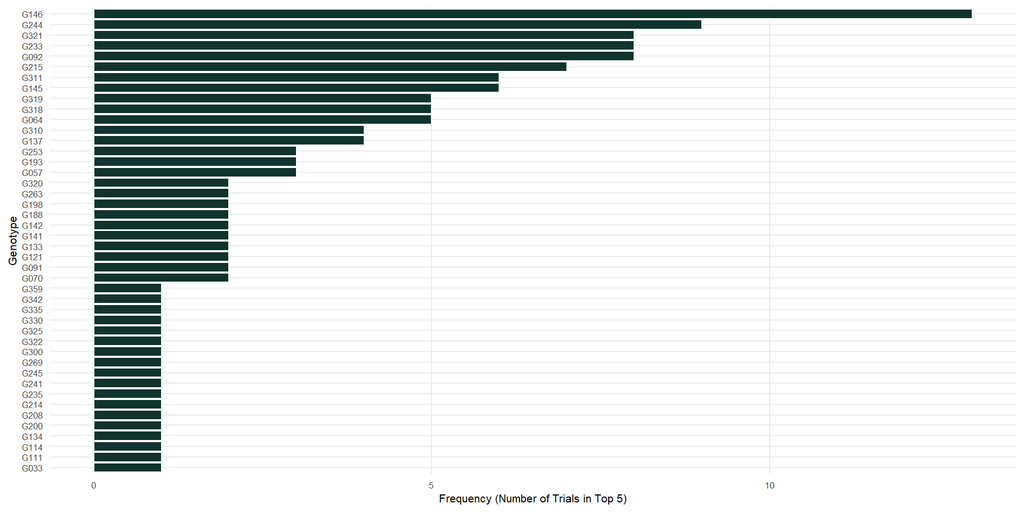

Figure 8: Frequency of each soybean breeding genotype in the top five genotypes in each trial for Plant Height in Zambia.

```r
frequencia_geral_ph <- tabela_larga |>
  select(env, ends_with("_gen")) |>
  pivot_longer(cols = ends_with("_gen"), values_to = "genotipo") |>
  count(genotipo, name = "total_ambientes") |>
  arrange(desc(total_ambientes))

ggplot(data = frequencia_geral_ph, aes(x = total_ambientes, y = reorder(genotipo, total_ambientes))) +
  geom_col(color = "white", fill = "#10342d") +
  theme_minimal() +
  labs(
    x = "Frequency (Number of Trials in Top 5)",
    y = "Genotype"
  ) +
  theme(
    text = element_text(size = 8),
    panel.grid.minor = element_blank()
  )
```

As observed for the previous trait, Plant Height (PH) values varied considerably among trials. This is further evidenced by tracking individual high-ranking lines across different environmental conditions in Table 8.

```r
G146 <- tabela_longa |> select(gen, env, rank, predicted.value) |> filter(gen == "G146") |> arrange(rank)
kable(G146,
      align = "c",
      col.names = c("Genotype","Trial", "Rank position", "Predicted value")) |>
kable_styling(bootstrap_options = c("striped", "hover", "condensed"), full_width = FALSE)

G244 <- tabela_longa |> select(gen, env, rank, predicted.value) |> filter(gen == "G244") |> arrange(rank)
kable(G244,
      align = "c",
      col.names = c("Genotype","Trial", "Rank position", "Predicted value")) |>
kable_styling(bootstrap_options = c("striped", "hover", "condensed"), full_width = FALSE)
```

Table 8: Behavior of high-ranking genotypes across specific environmental trials.

| Genotype | Trial | Rank position | Predicted value |
| --- | --- | --- | --- |
| G146 | E0284 | 1st | 109.12023 |
| G146 | E0279 | 1st | 101.64790 |
| G146 | E0280 | 1st | 93.26165 |
| G146 | E0175 | 1st | 67.58814 |
| G146 | E0173 | 2nd | 103.55567 |
| G146 | E0282 | 2nd | 89.27529 |
| G146 | E0255 | 2nd | 109.43789 |
| G146 | E0169 | 2nd | 91.87841 |
| G146 | E0104 | 2nd | 99.89118 |
| G146 | E0281 | 4th | 87.19144 |
| G146 | E0107 | 4th | 28.46500 |
| G146 | E0229 | 5th | 85.04859 |
| G146 | E0285 | 5th | 59.37495 |

| Genotype | Trial | Rank position | Predicted value |
| --- | --- | --- | --- |
| G244 | E0278 | 1st | 101.50599 |
| G244 | E0283 | 1st | 60.48247 |
| G244 | E0224 | 2nd | 91.53259 |
| G244 | E0229 | 3rd | 88.06960 |
| G244 | E0282 | 4th | 86.03829 |
| G244 | E0285 | 4th | 60.23889 |
| G244 | E0175 | 4th | 60.62023 |
| G244 | E0253 | 4th | 64.12253 |
| G244 | E0252 | 4th | 64.29114 |

When we take a closer analysis of the specific behavior of genotypes `G146` and `G244`, the environmental effect on plant height becomes clearer. We can observe that genotype `G146` appears exceptionally frequently at the top of the ranking, occupying the 1st or 2nd position in different new trials. However, its predicted height is highly variable; it reaches approximately 109 cm in highly designed environments such as `E0284` and `E0255`, but suffers a drastic reduction to only 28.4 cm in trial `E0107`.

Similarly, we note that genotype `G244` secures the 1st position in both `E0278` and `E0283`, but its absolute height in these two environments shows a large contrast (101.5 cm versus 60.4 cm). This indicates that, although these genotypes are consistently among the tallest in their various trials, their absolute growth is greatly influenced by the specific conditions of each location.

From a practical agronomic point of view, we emphasize that this level of phenotypic plasticity is a critical factor for selection. A plant height of 28.4 cm (as observed for `G146`) is generally too low for efficient mechanized harvesting, leading to potential yield losses in the field. On the other hand, heights exceeding 100 cm can increase the risk of lodging, depending on stem architecture. Therefore, we conclude that, although these lines exhibit strong genetic potential for growth, identifying and understanding the environmental stresses that cause these drastic height reductions is essential before making any safe varietal recommendations for Zambian environments.

# Cross-Trait Ranking Comparison: GY vs PH

To formally assess whether genotype rankings for Grain Yield (GY) and Plant Height (PH) are associated within each trial, we computed the Spearman rank correlation coefficient ($\rho$) between the BLUPs of both traits for each environment independently. This non-parametric approach is appropriate given that it does not assume a linear relationship between the traits, relying solely on the rank order of genotypes. A positive ρ indicates that taller genotypes tend to also yield more within that trial, whereas a negative ρ suggests a trade-off between the two traits.

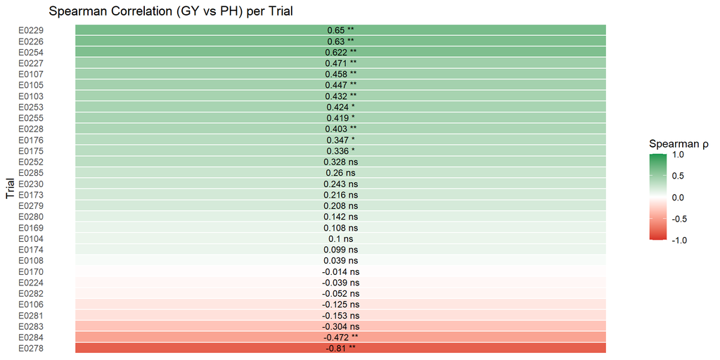

Figure 9: Spearman rank correlation between GY and PH BLUPs within each trial.

```r
# Trials presentes em ambos os traits
trials_comuns <- intersect(names(singleTrial_blup_GY), names(singleTrial_blup_PH))

# Correlação de Spearman em loop
spearman_results <- map_dfr(trials_comuns, function(env) {

  blup_gy <- singleTrial_blup_GY[[env]] |>
    select(gen, GY = predicted.value)

  blup_ph <- singleTrial_blup_PH[[env]] |>
    select(gen, PH = predicted.value)

  merged <- inner_join(blup_gy, blup_ph, by = "gen")

  if (nrow(merged) < 5) return(NULL)

  test <- cor.test(merged$GY, merged$PH, method = "spearman", exact = FALSE)

  data.frame(
    env      = env,
    rho      = round(test$estimate, 3),
    pvalue   = round(test$p.value, 4),
    sig      = case_when(
      test$p.value < 0.01 ~ "**",
      test$p.value < 0.05 ~ "*",
      TRUE                ~ "ns"
    ),
    n_gen    = nrow(merged)
  )
})

# Heatmap
ggplot(spearman_results, aes(x = 1, y = reorder(env, rho), fill = rho)) +
  geom_tile(color = "white", linewidth = 0.5) +
  geom_text(aes(label = paste0(rho, " ", sig)), size = 3.2) +
  scale_fill_gradient2(
    low      = "#d73027",
    mid      = "white",
    high     = "#1a9850",
    midpoint = 0,
    limits   = c(-1, 1),
    name     = "Spearman ρ"
  ) +
  labs(
    title = "Spearman Correlation (GY vs PH) per Trial",
    x     = NULL,
    y     = "Trial"
  ) +
  theme_minimal() +
  theme(
    axis.text.x  = element_blank(),
    axis.ticks.x = element_blank(),
    panel.grid   = element_blank(),
    text         = element_text(size = 11)
  )
```

The predominantly positive correlations may reflect a shared dependence on biomass accumulation, in favorable environments, genotypes with greater vegetative growth tend to simultaneously achieve higher grain yields. Conversely, the strong negative correlations observed in `E0278` and `E0284` suggest that in those specific conditions, taller genotypes may have allocated more photoassimilates to vegetative structures at the expense of grain filling, a classical source-sink competition pattern. Or possibly, that taller genotypes had problems with lodging, which decreases the grain yield. Overall, these results reinforce that multi-trait evaluation across environments is essential, as the GY–PH relationship is highly context-dependent and cannot be assumed to be consistent across the Zambian target population of environments.

# Conclusion

Significant changes in genotype ranking across locations definitively established Genotype-Environment (GxE) interaction as a primary factor in phenotypic expression across the target population of Zambian environments. This was illustrated by the contrasting adaptive strategies of the best-performing lines: for GY, the `G092` genotype demonstrated remarkable stability across trials, while `G233` exhibited high phenotypic plasticity, ranging from a peak of 4,825.4 kg/ha under highly favorable conditions to 1,935.7 kg/ha in restrictive environments. A similar pattern was observed for PH, where the `G146` genotype ranged from an optimal value of 109.1 cm to a severely stunted value of 28.4 cm, with direct implications for mechanical harvesting efficiency and lodging risk.

To formally quantify the relationship between trait ratings, we calculated Spearman correlations between the BLUPs of GY and PH in each trial. The coefficients ranged from $\rho$ = −0.81 (`E0278`) to $\rho$ = 0.65 (`E0229`), with 14 of the 30 trials showing statistically significant associations (p < 0.05). The predominantly positive correlations in favorable environments suggest a shared dependence on biomass accumulation, while the strong negative values observed in `E0278` and `E0284` point to a source-sink competition between vegetative growth and grain filling under specific conditions. Overall, the GY–PH relationship proved to be highly context-dependent, reinforcing that selection for a single trait would be insufficient for this target population.

Trait consensus analysis identified genotypes `G092` and `G233` as the most promising candidates for advancement in Zambia’s breeding program. The `G092` line consistently ranked among the best performers for both grain yield (GY) and plant height (PH) in multiple environments, suggesting broad adaptation and stability. The `G233` line, despite its plasticity, achieved peak performance, making it a strong candidate for targeted deployment in high-yielding Target Populations (TPEs). Together, these results highlight the value of multi-environmental and multi-trait assessment under a mixed model framework as a basis for informed and reliable selection decisions in soybean breeding programs.